# Investigation of Gapminder Datasets

##### Exploring Indicators for Mean Years in School (Women 25 to 34 years) with GDP per capita, Life expectancy and Urban population

#### Stephanie Anderton

> DAND Project 3  
> *June 2018*
- Introduction
- Data Wrangling
- Function Definitions
- Data Files
- Data Assessment
- Data Cleaning
- Exploratory Data Analysis
- How have Mean years in school for women changed over time?
- How does Mean years in school for women compare to that for men?
- What region has seen Mean years in school for women increase the most?
- Which countries have seen the greatest increase in Mean years in school for women?
- What variables are associated with the countries that have seen the greatest increase in Mean years in school for women?
- How does Mean years in school for women relate to Life expectancy and GDP?
- Conclusions
- References

## Introduction

The datasets selected for this report are from the Education and Population categories along with GDP and Life expectancy from Gapminder.org. These datasets contain annual data for countries as a whole and vary in dimension, source and provider. The number of years collected, as well as the number of countries and completeness of data varies greatly. It may be organizational, political and/or financial resources that make the collection of data possible, so it is likely that the results tend to favour stronger more affluent countries. The focus of this investigation is to see whether schooling for women has changed over time and how years in school for women relates to Urban population, Life expectancy and GDP per capita.

The Gapminder.org's Indicator datasets chosen for this investigation are (with Data provider):

- Mean years in school (men 25 to 34 years) | IHME (Institute for Health Metrics and Evaluation)
- Mean years in school (women 25 to 34 years) | IHME
- GDP/capita (US$, inflation-adjusted) | World Bank
- Life expectancy (years) | Various sources
- Urban population (% of total) | World Bank

The investigation attempts to answer these questions:

1. How have Mean years in school for women changed over time?
2. How does Mean years in school for women compare to that for men?
3. What region has seen Mean years in school for women increase the most?
4. Which countries have seen the greatest increase in Mean years in school for women?
5. What variables are associated with the countries that have seen the greatest increase in Mean years in school for women?
6. How does Mean years in school for women relate to Life expectancy?

To answer the questions the wider region as well as country levels was considered, using region categories taken from [Data Geographies - v1 - by Gapminder.xlsx](http://gapm.io/dl_geo), an Excel file that Gapminder also provides. It can be downloaded from the [Geography](https://www.gapminder.org/data/geo/) page, which can be navigated to from a link on the main [Data](https://www.gapminder.org/data/) page.

```python
# Import packages

import numpy as np
import pandas as pd

import matplotlib.pyplot as plt
from matplotlib import cm
%matplotlib inline

import seaborn as sns
sns.set(style="darkgrid")

##################################################
# Import local python file

import sa_gapminder as my
my.version()
```

```
sa_gapminder - build 38
```

### Function Definitions

Function definitions are located in a separate python file `sa_gapminder.py`, and imported along with the other required libraries. These functions are:

> ```
> convert_xls_to_csv(file_xls, file_csv)
> valid_args(df, years=None, threshold=20, limit=3)
> create_sub_df(df, list_cols, prepend_str)
> print_info(df, year)
> trim_cols(df, list_cols, verbose=False)
> transpose_df(df, column_type)
> clean_missing_data(df, threshold, limit, verbose=False)
> trim_and_clean(df_raw, start_year, threshold, limit, verbose=False)
> ```

### Data Files

#### File Preparation

Files for each indicator were downloaded from Gapminder.org in `.xlsx` format, and are then converted to `.csv` using the `my.convert_xls_to_csv` function imported in this notebook. Only the sheet titled `List of countries` was saved to the `.csv`. The original files, converted files (raw) and clean `.csv` files are all saved in the same folder as this notebook.

Most of the original Gapminder data files contained a string with the file's title in the first cell, **A1**; this is replaced with the string "Country" during the conversion function before saving the `.csv` file.

> **Note:** The **Convert .XLS files to .CSV** *block below need only be run the first time in this notebook. It can be skipped on subsequent runs as the* `.csv` *files will have been created. The converted datasets can be loaded from the* Load .CSV files *block below.*

#### Convert .XLS files to .CSV

```python
df_gdp_raw = my.convert_xls_to_csv('GDPpercapitaconstant2000US.xlsx', 'gdp_per_capita.csv')
df_life_raw = my.convert_xls_to_csv('indicator life_expectancy_at_birth.xlsx', 'life_expectancy.csv')
df_edu_m_raw = my.convert_xls_to_csv('Years in school men 25-34.xlsx', 'school_years_men.csv')
df_edu_w_raw = my.convert_xls_to_csv('Years in school women 25-34.xlsx', 'school_years_women.csv')
df_urban_popn_raw = my.convert_xls_to_csv('indicator wdi urbanpopulation.xlsx', 'urban_popn.csv')
```

```python
xlsx = pd.ExcelFile('Data Geographies - v1 - by Gapminder.xlsx')
df_regions_raw = pd.read_excel(xlsx, 'List of countries')
df_regions_raw.to_csv('regions.csv', index=False)
```

#### Load .CSV files

These are the converted `.XLS` files, which are used for this investigation.

```python
df_gdp_raw = pd.read_csv('gdp_per_capita.csv')
df_life_raw = pd.read_csv('life_expectancy.csv')
df_edu_m_raw = pd.read_csv('school_years_men.csv')
df_edu_w_raw = pd.read_csv('school_years_women.csv')
df_urban_popn_raw = pd.read_csv('urban_popn.csv')

df_regions_raw = pd.read_csv('regions.csv')
```

Dataframe names ending with `_raw` contain the original data from the converted Gapminder data files. Dataframes without this ending are used for the assessment and analysis process.

After the datasets have been cleaned they are saved to a new `.csv` file with `_clean` appended to the filename. These `_clean` files can then be loaded for subsequent investigations.

| dataframe | Description |
| --- | --- |
| **df_gdp** | GDP/capita (US$, inflation-adjusted) |
| **df_life** | Life expectancy from birth |
| **df_edu_m** | Mean years in school, (men 25 to 34 years) |
| **df_edu_w** | Mean years in school, (women 25 to 34 years) |
| **df_urban_popn** | Urban population (% of total) |
| **df_regions** | Use to get the countries' region information |

#### Regions

Three columns will be used from the regions dataset: these are 'name', 'eight_regions' and 'World bank income group 2017'. All other columns will be dropped.

```python
df_regions_raw.head(1)
```

|  | geo | name | four_regions | eight_regions | six_regions | members_oecd_g77 | Latitude | Longitude | UN member since | World bank region | World bank income group 2017 |
| --- | --- | --- | --- | --- | --- | --- | --- | --- | --- | --- | --- |
| 0 | afg | Afghanistan | asia | asia_west | south_asia | g77 | 33.0 | 66.0 | 1946-11-19 | South Asia | Low income |

```python
df_regions = df_regions_raw.drop(['geo', 'four_regions', 'six_regions', 'members_oecd_g77', 'Latitude', 'Longitude',
                                  'UN member since', 'World bank region'], axis=1)
df_regions.rename(columns={'name': 'Country', 'eight_regions': 'region', 'World bank income group 2017': 'income'}, inplace=True)
df_regions.head()
```

|  | Country | region | income |
| --- | --- | --- | --- |
| 0 | Afghanistan | asia_west | Low income |
| 1 | Albania | europe_east | Upper middle income |
| 2 | Algeria | africa_north | Upper middle income |
| 3 | Andorra | europe_west | High income |
| 4 | Angola | africa_sub_saharan | Lower middle income |

```python
df_regions['region'].value_counts()
```

```
africa_sub_saharan    48
east_asia_pacific     32
asia_west             27
europe_west           25
europe_east           24
america_north         23
america_south         12
africa_north           6
Name: region, dtype: int64
```

```python
df_regions['income'].value_counts()
```

```
High income            58
Upper middle income    55
Lower middle income    52
Low income             31
Name: income, dtype: int64
```

```python
print("shape      : ", df_regions.shape)
print("duplicates : ", df_regions.duplicated().sum())
```

```
shape      :  (197, 3)
duplicates :  0
```

```python
df_regions.to_csv('regions_clean.csv', index=False)
```

### Data Assessment

The datasets were assessed using some of these function calls:

`df.head() |` View the first 5 rows to check the data format  
`df.columns |` Display columns, to see what years are contained  
`df.shape |` Get the shape of the dataframe (rows, columns)  
`df.describe() |` Display summary statistics by column  
`df.max(axis=1).max() |` Max value in the dataset, likewise for min value; use for outliers/errors  
`df.info() |` Description info on data types, non-nulls by column  
`df.isnull().sum().any() |` Check to see if there are any NaNs in the dataframe, True/False  
`df.isnull().any(axis=1).sum() |` Number of countries with NaNs  
`df.isnull().any().sum() |` Number of years with NaNs

Skip to Data Cleaning, Exploratory Data Analysis

#### Duplicates Check

```python
print("duplicates in GDP_per_capita.csv        : ", df_gdp_raw.duplicated().sum())
print("duplicates in life_expectancy.csv       : ", df_life_raw.duplicated().sum())
print("duplicates in school_years_men.csv      : ", df_edu_m_raw.duplicated().sum())
print("duplicates in school_years_women.csv    : ", df_edu_w_raw.duplicated().sum())
print("duplicates in urban_popn.csv            : ", df_urban_popn_raw.duplicated().sum())
```

```
duplicates in GDP_per_capita.csv        :  0
duplicates in life_expectancy.csv       :  0
duplicates in school_years_men.csv      :  0
duplicates in school_years_women.csv    :  0
duplicates in urban_popn.csv            :  0
```

#### Data Types Check

>

> Results from calling `df.info()` on all the datasets showed that the data types of all the year columns are `float64`, and the 'Country' column contains an `object` type of `str` (string).

> **Note:** This call was included only on the first dataset presented to save space.

#### Assessing the dataset: Mean years in school (men 25 to 34 years)

```python
df_edu_m_raw.head()
```

|  | Country | 1970 | 1971 | 1972 | 1973 | 1974 | 1975 | 1976 | 1977 | 1978 | ... | 2000 | 2001 | 2002 | 2003 | 2004 | 2005 | 2006 | 2007 | 2008 | 2009 |
| --- | --- | --- | --- | --- | --- | --- | --- | --- | --- | --- | --- | --- | --- | --- | --- | --- | --- | --- | --- | --- | --- |
| 0 | Afghanistan | 1.0 | 1.1 | 1.1 | 1.2 | 1.3 | 1.3 | 1.4 | 1.4 | 1.5 | ... | 2.8 | 2.9 | 2.9 | 3.0 | 3.0 | 3.1 | 3.1 | 3.2 | 3.3 | 3.3 |
| 1 | Albania | 6.5 | 6.7 | 6.9 | 7.0 | 7.2 | 7.3 | 7.5 | 7.7 | 7.8 | ... | 10.4 | 10.4 | 10.5 | 10.6 | 10.7 | 10.7 | 10.8 | 10.9 | 10.9 | 11.0 |
| 2 | Algeria | 1.9 | 2.0 | 2.1 | 2.2 | 2.3 | 2.4 | 2.5 | 2.7 | 2.8 | ... | 6.3 | 6.5 | 6.6 | 6.7 | 6.8 | 7.0 | 7.1 | 7.2 | 7.3 | 7.3 |
| 3 | Angola | 2.3 | 2.4 | 2.5 | 2.7 | 2.8 | 2.9 | 3.0 | 3.1 | 3.2 | ... | 5.5 | 5.6 | 5.7 | 5.8 | 5.8 | 5.9 | 6.0 | 6.0 | 6.1 | 6.2 |
| 4 | Antigua and Barbuda | 8.0 | 8.2 | 8.4 | 8.6 | 8.7 | 8.9 | 9.1 | 9.3 | 9.5 | ... | 12.5 | 12.6 | 12.7 | 12.8 | 12.8 | 12.9 | 13.0 | 13.0 | 13.1 | 13.2 |

5 rows × 41 columns

The data appears to have been converted correctly: countries are in column 1, and the year data runs across the columns.

```python
df_edu_m_raw.info()
```

```
<class 'pandas.core.frame.DataFrame'>
RangeIndex: 175 entries, 0 to 174
Data columns (total 41 columns):
Country    175 non-null object
1970       175 non-null float64
1971       175 non-null float64
1972       175 non-null float64
1973       175 non-null float64
1974       175 non-null float64
1975       175 non-null float64
1976       175 non-null float64
1977       175 non-null float64
1978       175 non-null float64
1979       175 non-null float64
1980       175 non-null float64
```

[output cut: 31 more lines]

```python
type(df_edu_m_raw['Country'][0])
```

```
str
```

The call to `df.info()` shows the data types in all the year columns are float64, and the 'Country' column contains object type of string. There are also columns for each year, uninterrupted from 1970 to 2009.

```python
df_edu_m_raw.describe()
```

|  | 1970 | 1971 | 1972 | 1973 | 1974 | 1975 | 1976 | 1977 | 1978 | 1979 | ... | 2000 | 2001 | 2002 | 2003 | 2004 | 2005 | 2006 | 2007 | 2008 | 2009 |
| --- | --- | --- | --- | --- | --- | --- | --- | --- | --- | --- | --- | --- | --- | --- | --- | --- | --- | --- | --- | --- | --- |
| count | 175.000000 | 175.000000 | 175.000000 | 175.000000 | 175.000000 | 175.000000 | 175.000000 | 175.000000 | 175.000000 | 175.000000 | ... | 175.000000 | 175.00000 | 175.000000 | 175.000000 | 175.000000 | 175.000000 | 175.000000 | 175.000000 | 175.000000 | 175.000000 |
| mean | 5.094286 | 5.242857 | 5.393714 | 5.541714 | 5.692000 | 5.841143 | 5.986286 | 6.130857 | 6.274857 | 6.416000 | ... | 8.818857 | 8.92000 | 9.008000 | 9.091429 | 9.173714 | 9.262286 | 9.340571 | 9.416000 | 9.494286 | 9.568571 |
| std | 2.653185 | 2.688063 | 2.723781 | 2.754626 | 2.784841 | 2.814070 | 2.839912 | 2.863016 | 2.884470 | 2.900015 | ... | 2.928347 | 2.92038 | 2.914459 | 2.911785 | 2.904217 | 2.895946 | 2.893137 | 2.891242 | 2.881365 | 2.876038 |
| min | 0.400000 | 0.400000 | 0.500000 | 0.500000 | 0.500000 | 0.500000 | 0.600000 | 0.600000 | 0.600000 | 0.700000 | ... | 2.000000 | 2.10000 | 2.200000 | 2.200000 | 2.300000 | 2.400000 | 2.500000 | 2.500000 | 2.600000 | 2.700000 |
| 25% | 2.850000 | 2.950000 | 3.100000 | 3.250000 | 3.350000 | 3.450000 | 3.600000 | 3.700000 | 3.800000 | 3.900000 | ... | 6.350000 | 6.50000 | 6.600000 | 6.700000 | 6.750000 | 6.900000 | 7.000000 | 7.100000 | 7.250000 | 7.300000 |
| 50% | 4.800000 | 5.000000 | 5.200000 | 5.300000 | 5.500000 | 5.600000 | 5.800000 | 5.900000 | 6.100000 | 6.300000 | ... | 9.200000 | 9.30000 | 9.400000 | 9.500000 | 9.600000 | 9.700000 | 9.700000 | 9.800000 | 9.900000 | 10.000000 |
| 75% | 7.300000 | 7.450000 | 7.650000 | 7.850000 | 8.050000 | 8.300000 | 8.450000 | 8.650000 | 8.850000 | 8.950000 | ... | 11.450000 | 11.55000 | 11.650000 | 11.650000 | 11.750000 | 11.800000 | 11.850000 | 11.900000 | 12.000000 | 12.100000 |
| max | 12.500000 | 12.600000 | 12.600000 | 12.700000 | 12.800000 | 12.800000 | 12.900000 | 13.000000 | 13.000000 | 13.100000 | ... | 14.300000 | 14.40000 | 14.400000 | 14.500000 | 14.600000 | 14.600000 | 14.700000 | 14.700000 | 14.800000 | 14.800000 |

8 rows × 40 columns

```python
my.print_info(df_edu_m_raw, '1970')
```

```
Details for dataframe starting from year:       1970
Shape of dataframe (rows, columns):             (175, 40)
Min and Max values:                             0.4 ,  14.8
Total number of countries with NaNs:            0
Total number of years with NaNs:                0
```

From the results of `df.describe()` the means, percentile ranges and the min, max values are all within a reasonable range for Mean years of school. The dataset has 175 rows for countries, and does not contain any NaN entries.

#### Assessing the dataset: Mean years in school (women 25 to 34 years)

```python
df_edu_w_raw.head()
```

|  | Country | 1970 | 1971 | 1972 | 1973 | 1974 | 1975 | 1976 | 1977 | 1978 | ... | 2000 | 2001 | 2002 | 2003 | 2004 | 2005 | 2006 | 2007 | 2008 | 2009 |
| --- | --- | --- | --- | --- | --- | --- | --- | --- | --- | --- | --- | --- | --- | --- | --- | --- | --- | --- | --- | --- | --- |
| 0 | Afghanistan | 0.1 | 0.1 | 0.1 | 0.1 | 0.1 | 0.1 | 0.1 | 0.1 | 0.1 | ... | 0.4 | 0.4 | 0.4 | 0.4 | 0.5 | 0.5 | 0.5 | 0.5 | 0.6 | 0.6 |
| 1 | Albania | 6.0 | 6.2 | 6.3 | 6.5 | 6.6 | 6.8 | 6.9 | 7.1 | 7.2 | ... | 10.2 | 10.3 | 10.4 | 10.5 | 10.6 | 10.6 | 10.7 | 10.8 | 10.9 | 11.0 |
| 2 | Algeria | 1.4 | 1.5 | 1.6 | 1.7 | 1.8 | 1.9 | 2.0 | 2.1 | 2.3 | ... | 5.8 | 6.0 | 6.1 | 6.2 | 6.4 | 6.5 | 6.6 | 6.7 | 6.8 | 6.9 |
| 3 | Angola | 1.0 | 1.1 | 1.1 | 1.2 | 1.2 | 1.3 | 1.3 | 1.4 | 1.5 | ... | 3.6 | 3.7 | 3.8 | 3.9 | 4.0 | 4.1 | 4.2 | 4.3 | 4.4 | 4.5 |
| 4 | Antigua and Barbuda | 8.1 | 8.3 | 8.5 | 8.7 | 8.9 | 9.1 | 9.3 | 9.5 | 9.7 | ... | 13.0 | 13.1 | 13.2 | 13.2 | 13.3 | 13.4 | 13.5 | 13.5 | 13.6 | 13.7 |

5 rows × 41 columns

```python
df_edu_w_raw.columns
```

```
Index(['Country', '1970', '1971', '1972', '1973', '1974', '1975', '1976',
       '1977', '1978', '1979', '1980', '1981', '1982', '1983', '1984', '1985',
       '1986', '1987', '1988', '1989', '1990', '1991', '1992', '1993', '1994',
       '1995', '1996', '1997', '1998', '1999', '2000', '2001', '2002', '2003',
       '2004', '2005', '2006', '2007', '2008', '2009'],
      dtype='object')
```

```python
df_edu_w_raw.describe()
```

|  | 1970 | 1971 | 1972 | 1973 | 1974 | 1975 | 1976 | 1977 | 1978 | 1979 | ... | 2000 | 2001 | 2002 | 2003 | 2004 | 2005 | 2006 | 2007 | 2008 | 2009 |
| --- | --- | --- | --- | --- | --- | --- | --- | --- | --- | --- | --- | --- | --- | --- | --- | --- | --- | --- | --- | --- | --- |
| count | 175.000000 | 175.000000 | 175.000000 | 175.000000 | 175.000000 | 175.000000 | 175.000000 | 175.000000 | 175.000000 | 175.000000 | ... | 175.000000 | 175.000000 | 175.000000 | 175.000000 | 175.000000 | 175.000000 | 175.000000 | 175.000000 | 175.000000 | 175.000000 |
| mean | 3.985143 | 4.125143 | 4.268571 | 4.409143 | 4.554857 | 4.699429 | 4.838857 | 4.982286 | 5.129714 | 5.276000 | ... | 8.106286 | 8.224000 | 8.343429 | 8.460000 | 8.572571 | 8.682286 | 8.796000 | 8.904571 | 9.008571 | 9.111429 |
| std | 2.913762 | 2.973590 | 3.036613 | 3.092989 | 3.146238 | 3.202110 | 3.254807 | 3.303164 | 3.353901 | 3.395839 | ... | 3.779956 | 3.788867 | 3.786675 | 3.788898 | 3.787008 | 3.786740 | 3.787295 | 3.781319 | 3.781851 | 3.775828 |
| min | 0.100000 | 0.100000 | 0.100000 | 0.100000 | 0.100000 | 0.100000 | 0.100000 | 0.100000 | 0.100000 | 0.100000 | ... | 0.400000 | 0.400000 | 0.400000 | 0.400000 | 0.500000 | 0.500000 | 0.500000 | 0.500000 | 0.600000 | 0.600000 |
| 25% | 1.350000 | 1.450000 | 1.500000 | 1.600000 | 1.700000 | 1.800000 | 1.900000 | 2.000000 | 2.100000 | 2.250000 | ... | 4.800000 | 4.900000 | 5.000000 | 5.100000 | 5.300000 | 5.400000 | 5.500000 | 5.700000 | 5.850000 | 6.000000 |
| 50% | 3.600000 | 3.700000 | 3.900000 | 4.000000 | 4.200000 | 4.400000 | 4.600000 | 4.700000 | 4.900000 | 5.100000 | ... | 8.700000 | 8.900000 | 9.100000 | 9.200000 | 9.400000 | 9.500000 | 9.700000 | 9.800000 | 10.000000 | 10.100000 |
| 75% | 6.500000 | 6.650000 | 6.850000 | 7.050000 | 7.250000 | 7.400000 | 7.650000 | 7.850000 | 8.050000 | 8.250000 | ... | 11.500000 | 11.600000 | 11.700000 | 11.800000 | 11.900000 | 12.000000 | 12.100000 | 12.200000 | 12.250000 | 12.350000 |
| max | 12.000000 | 12.100000 | 12.200000 | 12.300000 | 12.400000 | 12.500000 | 12.600000 | 12.600000 | 12.700000 | 12.800000 | ... | 14.500000 | 14.600000 | 14.600000 | 14.700000 | 14.800000 | 14.800000 | 14.900000 | 14.900000 | 15.000000 | 15.000000 |

8 rows × 40 columns

```python
my.print_info(df_edu_w_raw, '1970')
```

```
Details for dataframe starting from year:       1970
Shape of dataframe (rows, columns):             (175, 40)
Min and Max values:                             0.1 ,  15.0
Total number of countries with NaNs:            0
Total number of years with NaNs:                0
```

From the results of `df.describe()` the means, percentile ranges and the min, max values are all within a reasonable range for Mean years of school. The dataset has 175 rows for countries, and does not contain any NaN entries.

#### Assessing the dataset: Life expectancy (years)

```python
df_life_raw.head()
```

|  | Country | 1800 | 1801 | 1802 | 1803 | 1804 | 1805 | 1806 | 1807 | 1808 | ... | 2007 | 2008 | 2009 | 2010 | 2011 | 2012 | 2013 | 2014 | 2015 | 2016 |
| --- | --- | --- | --- | --- | --- | --- | --- | --- | --- | --- | --- | --- | --- | --- | --- | --- | --- | --- | --- | --- | --- |
| 0 | Abkhazia | NaN | NaN | NaN | NaN | NaN | NaN | NaN | NaN | NaN | ... | NaN | NaN | NaN | NaN | NaN | NaN | NaN | NaN | NaN | NaN |
| 1 | Afghanistan | 28.21 | 28.20 | 28.19 | 28.18 | 28.17 | 28.16 | 28.15 | 28.14 | 28.13 | ... | 52.4 | 52.8 | 53.3 | 53.6 | 54.0 | 54.4 | 54.8 | 54.9 | 53.8 | 52.72 |
| 2 | Akrotiri and Dhekelia | NaN | NaN | NaN | NaN | NaN | NaN | NaN | NaN | NaN | ... | NaN | NaN | NaN | NaN | NaN | NaN | NaN | NaN | NaN | NaN |
| 3 | Albania | 35.40 | 35.40 | 35.40 | 35.40 | 35.40 | 35.40 | 35.40 | 35.40 | 35.40 | ... | 76.6 | 76.8 | 77.0 | 77.2 | 77.4 | 77.5 | 77.7 | 77.9 | 78.0 | 78.10 |
| 4 | Algeria | 28.82 | 28.82 | 28.82 | 28.82 | 28.82 | 28.82 | 28.82 | 28.82 | 28.82 | ... | 75.3 | 75.5 | 75.7 | 76.0 | 76.1 | 76.2 | 76.3 | 76.3 | 76.4 | 76.50 |

5 rows × 218 columns

The Life exptectancy dataset contains far more data than is required for this investigation; all columns for years prior to 1970 will eventually be dropped so as to have the same time period as the other datasets. For assessment purposes only the filtered time period will be looked at.

```python
df_life_raw.loc[:, '1970':].describe()
```

|  | 1970 | 1971 | 1972 | 1973 | 1974 | 1975 | 1976 | 1977 | 1978 | 1979 | ... | 2007 | 2008 | 2009 | 2010 | 2011 | 2012 | 2013 | 2014 | 2015 | 2016 |
| --- | --- | --- | --- | --- | --- | --- | --- | --- | --- | --- | --- | --- | --- | --- | --- | --- | --- | --- | --- | --- | --- |
| count | 202.000000 | 202.000000 | 202.000000 | 202.000000 | 202.000000 | 202.000000 | 202.000000 | 202.000000 | 202.000000 | 202.000000 | ... | 208.000000 | 208.000000 | 208.000000 | 208.000000 | 208.000000 | 208.000000 | 208.000000 | 208.000000 | 208.00000 | 208.000000 |
| mean | 59.238564 | 59.679752 | 60.104257 | 60.483911 | 60.871634 | 61.199653 | 61.611683 | 62.031089 | 62.420000 | 62.830297 | ... | 70.139712 | 70.447163 | 70.767740 | 70.969904 | 71.324375 | 71.663077 | 71.916106 | 72.088125 | 72.32101 | 72.556635 |
| std | 10.461449 | 10.343012 | 10.275164 | 10.200084 | 10.152239 | 10.234447 | 10.153307 | 10.101591 | 9.966088 | 9.820317 | ... | 8.953255 | 8.800452 | 8.610341 | 8.898859 | 8.376540 | 8.217466 | 8.120852 | 8.074990 | 7.90202 | 7.738535 |
| min | 34.510000 | 35.270000 | 36.040000 | 36.820000 | 34.940000 | 21.690000 | 19.040000 | 18.100000 | 19.550000 | 21.910000 | ... | 43.300000 | 44.500000 | 45.500000 | 32.200000 | 46.700000 | 46.100000 | 45.600000 | 45.400000 | 47.10000 | 48.860000 |
| 25% | 50.417500 | 50.787500 | 51.110000 | 51.357500 | 51.712500 | 52.205000 | 52.787500 | 53.537500 | 54.232500 | 54.792500 | ... | 64.825000 | 64.875000 | 65.225000 | 65.475000 | 65.600000 | 66.075000 | 66.475000 | 66.775000 | 67.05000 | 67.175000 |
| 50% | 61.185000 | 61.960000 | 62.520000 | 63.020000 | 63.465000 | 64.160000 | 64.435000 | 64.840000 | 65.250000 | 65.675000 | ... | 72.750000 | 73.000000 | 73.350000 | 73.700000 | 73.750000 | 74.050000 | 74.150000 | 74.300000 | 74.40000 | 74.500000 |
| 75% | 68.737500 | 69.000000 | 69.207500 | 69.422500 | 69.620000 | 69.827500 | 70.025000 | 70.377500 | 70.680000 | 70.815000 | ... | 76.925000 | 77.150000 | 77.425000 | 77.650000 | 77.825000 | 78.125000 | 78.300000 | 78.400000 | 78.50000 | 78.650000 |
| max | 74.660000 | 74.580000 | 74.680000 | 74.830000 | 74.940000 | 75.570000 | 76.940000 | 76.350000 | 76.660000 | 76.880000 | ... | 84.500000 | 84.600000 | 84.600000 | 84.700000 | 84.700000 | 84.700000 | 84.800000 | 84.800000 | 84.80000 | 84.800000 |

8 rows × 47 columns

```python
my.print_info(df_life_raw, '1970')
```

```
Details for dataframe starting from year:       1970
Shape of dataframe (rows, columns):             (260, 47)
Min and Max values:                             13.2 ,  84.8
Total number of countries with NaNs:            58
Total number of years with NaNs:                47
```

From the results of `df.describe()` the means, percentile ranges and the min, max values are within a reasonable range for Life expectancy. The results from 1970 onwards indicate that there are NaNs in 58 out of 260 rows (countries), and in every column (47 years) of the dataset. Data cleaning will be done in the next section.

#### Assessing the dataset: Urban population (% of total)

```python
df_urban_popn_raw.head()
```

|  | Country | 1960 | 1961 | 1962 | 1963 | 1964 | 1965 | 1966 | 1967 | 1968 | ... | 2002 | 2003 | 2004 | 2005 | 2006 | 2007 | 2008 | 2009 | 2010 | 2011 |
| --- | --- | --- | --- | --- | --- | --- | --- | --- | --- | --- | --- | --- | --- | --- | --- | --- | --- | --- | --- | --- | --- |
| 0 | Abkhazia | NaN | NaN | NaN | NaN | NaN | NaN | NaN | NaN | NaN | ... | NaN | NaN | NaN | NaN | NaN | NaN | NaN | NaN | NaN | NaN |
| 1 | Afghanistan | 8.0 | 8.2650 | 8.5370 | 8.8090 | 9.0810 | 9.353 | 9.6886 | 10.0242 | 10.3598 | ... | 21.1026 | 21.3624 | 21.6222 | 21.882 | 22.1534 | 22.4248 | 22.6962 | 22.9676 | 23.239 | 23.5472 |
| 2 | Akrotiri and Dhekelia | NaN | NaN | NaN | NaN | NaN | NaN | NaN | NaN | NaN | ... | NaN | NaN | NaN | NaN | NaN | NaN | NaN | NaN | NaN | NaN |
| 3 | Albania | 30.7 | 30.8100 | 30.9150 | 31.0200 | 31.1250 | 31.230 | 31.3320 | 31.4340 | 31.5360 | ... | 43.7662 | 44.7788 | 45.7914 | 46.804 | 47.9076 | 49.0112 | 50.1148 | 51.2184 | 52.322 | 53.3846 |
| 4 | Algeria | 30.5 | 31.9366 | 33.3632 | 34.7898 | 36.2164 | 37.643 | 38.0144 | 38.3858 | 38.7572 | ... | 63.1478 | 64.3282 | 65.5086 | 66.689 | 67.7560 | 68.8230 | 69.8900 | 70.9570 | 72.024 | 72.8650 |

5 rows × 53 columns

The Urban population dataset contains more data than is required for this investigation; all columns for years prior to 1970 will eventually be dropped so as to have the same time period as the other datasets. For assessment purposes only the filtered time period will be looked at.

```python
df_urban_popn_raw.loc[:, '1970':].describe()
```

|  | 1970 | 1971 | 1972 | 1973 | 1974 | 1975 | 1976 | 1977 | 1978 | 1979 | ... | 2002 | 2003 | 2004 | 2005 | 2006 | 2007 | 2008 | 2009 | 2010 | 2011 |
| --- | --- | --- | --- | --- | --- | --- | --- | --- | --- | --- | --- | --- | --- | --- | --- | --- | --- | --- | --- | --- | --- |
| count | 210.000000 | 210.000000 | 210.000000 | 210.000000 | 210.000000 | 210.000000 | 210.00000 | 210.000000 | 210.000000 | 210.000000 | ... | 210.000000 | 210.000000 | 210.000000 | 210.000000 | 210.000000 | 210.000000 | 210.000000 | 210.000000 | 210.000000 | 210.000000 |
| mean | 42.122176 | 42.666722 | 43.211268 | 43.755813 | 44.300359 | 44.844905 | 45.33923 | 45.833554 | 46.327879 | 46.822204 | ... | 55.024453 | 55.323399 | 55.622345 | 55.921290 | 56.215641 | 56.509991 | 56.804342 | 57.098692 | 57.393043 | 57.691593 |
| std | 24.293300 | 24.336913 | 24.394234 | 24.465168 | 24.549595 | 24.647378 | 24.66217 | 24.685709 | 24.717970 | 24.758918 | ... | 24.457590 | 24.440579 | 24.429155 | 24.423326 | 24.391702 | 24.364500 | 24.341736 | 24.323422 | 24.309569 | 24.261384 |
| min | 2.382000 | 2.549200 | 2.716400 | 2.883600 | 3.050800 | 3.218000 | 3.44220 | 3.666400 | 3.890600 | 4.114800 | ... | 8.697600 | 8.923400 | 9.149200 | 9.375000 | 9.628400 | 9.881800 | 10.135200 | 10.388600 | 10.642000 | 10.928000 |
| 25% | 21.480250 | 21.914750 | 22.900900 | 23.201850 | 23.505900 | 24.048000 | 24.57935 | 25.162400 | 25.684350 | 26.257000 | ... | 34.158850 | 34.550900 | 34.905950 | 35.211250 | 35.612150 | 36.176650 | 36.622350 | 37.113300 | 37.604250 | 38.112700 |
| 50% | 39.622000 | 40.252200 | 40.940300 | 41.692200 | 42.382800 | 43.049500 | 43.52070 | 44.268700 | 45.030300 | 45.866800 | ... | 55.176000 | 55.567100 | 55.695400 | 55.748000 | 55.807000 | 56.089000 | 56.664500 | 57.149500 | 57.394500 | 57.690300 |
| 75% | 59.655000 | 60.401750 | 60.848750 | 61.353500 | 61.917550 | 62.765750 | 63.49030 | 64.095200 | 64.710300 | 65.208900 | ... | 73.863700 | 74.513200 | 75.358900 | 75.458500 | 75.494600 | 75.700100 | 75.962400 | 76.224700 | 76.582500 | 76.800150 |
| max | 100.000000 | 100.000000 | 100.000000 | 100.000000 | 100.000000 | 100.000000 | 100.00000 | 100.000000 | 100.000000 | 100.000000 | ... | 100.000000 | 100.000000 | 100.000000 | 100.000000 | 100.000000 | 100.000000 | 100.000000 | 100.000000 | 100.000000 | 100.000000 |

8 rows × 42 columns

```python
my.print_info(df_urban_popn_raw, '1970')
```

```
Details for dataframe starting from year:       1970
Shape of dataframe (rows, columns):             (273, 42)
Min and Max values:                             2.3819999999999997 ,  100.0
Total number of countries with NaNs:            63
Total number of years with NaNs:                42
```

From the results of `df.describe()` the means, percentile ranges and the min, max values are within the expected range for the Urban population data. The results from 1970 onwards indicate that there are NaNs in 63 out of 273 rows (countries), and in every column (42 years) of the dataset. Data cleaning will be done in the next section.

#### Assessing the dataset: GDP per capita

```python
df_gdp_raw.head()
```

|  | Country | 1960 | 1961 | 1962 | 1963 | 1964 | 1965 | 1966 | 1967 | 1968 | ... | 2002 | 2003 | 2004 | 2005 | 2006 | 2007 | 2008 | 2009 | 2010 | 2011 |
| --- | --- | --- | --- | --- | --- | --- | --- | --- | --- | --- | --- | --- | --- | --- | --- | --- | --- | --- | --- | --- | --- |
| 0 | Abkhazia | NaN | NaN | NaN | NaN | NaN | NaN | NaN | NaN | NaN | ... | NaN | NaN | NaN | NaN | NaN | NaN | NaN | NaN | NaN | NaN |
| 1 | Afghanistan | NaN | NaN | NaN | NaN | NaN | NaN | NaN | NaN | NaN | ... | NaN | NaN | NaN | NaN | NaN | NaN | NaN | NaN | NaN | NaN |
| 2 | Akrotiri and Dhekelia | NaN | NaN | NaN | NaN | NaN | NaN | NaN | NaN | NaN | ... | NaN | NaN | NaN | NaN | NaN | NaN | NaN | NaN | NaN | NaN |
| 3 | Albania | NaN | NaN | NaN | NaN | NaN | NaN | NaN | NaN | NaN | ... | 1313.722725 | 1381.040832 | 1454.022854 | 1525.723589 | 1594.495067 | 1681.613910 | 1804.419415 | 1857.352947 | 1915.424459 | 1965.707230 |
| 4 | Algeria | 1280.384828 | 1085.414612 | 855.947986 | 1128.41578 | 1170.323896 | 1215.015783 | 1127.614288 | 1200.558225 | 1291.863983 | ... | 1871.921986 | 1971.512803 | 2043.135713 | 2115.186028 | 2124.957754 | 2155.485231 | 2173.787903 | 2192.703976 | 2231.980246 | 2255.225482 |

5 rows × 53 columns

The GDP dataset contains a few more years of data than is needed for this investigation; all columns for years prior to 1970 will eventually be dropped so as to have the same time period as the other datasets. For assessment purposes only the filtered time period will be looked at in the following cells.

```python
df_gdp_raw.loc[:, '1970':].describe()
```

|  | 1970 | 1971 | 1972 | 1973 | 1974 | 1975 | 1976 | 1977 | 1978 | 1979 | ... | 2002 | 2003 | 2004 | 2005 | 2006 | 2007 | 2008 | 2009 | 2010 | 2011 |
| --- | --- | --- | --- | --- | --- | --- | --- | --- | --- | --- | --- | --- | --- | --- | --- | --- | --- | --- | --- | --- | --- |
| count | 119.000000 | 119.000000 | 119.000000 | 119.000000 | 120.000000 | 124.000000 | 125.000000 | 130.000000 | 130.000000 | 131.000000 | ... | 195.000000 | 195.000000 | 194.000000 | 194.000000 | 193.000000 | 193.000000 | 191.000000 | 189.000000 | 182.000000 | 175.000000 |
| mean | 4999.209729 | 5162.990420 | 5352.052764 | 5565.457970 | 5846.324250 | 6149.984437 | 6369.430049 | 6466.064863 | 6569.092736 | 6777.519169 | ... | 7983.084448 | 8113.092660 | 8335.349531 | 8545.104221 | 8898.582041 | 9219.106697 | 8999.106190 | 8463.079022 | 7699.995854 | 7603.241430 |
| std | 7485.619356 | 7703.432230 | 7923.187992 | 8255.847998 | 8531.552149 | 9470.092387 | 9766.800546 | 9953.065149 | 9866.611871 | 10310.876158 | ... | 12730.751887 | 12804.769377 | 13171.168298 | 13440.153560 | 14003.742573 | 14664.833399 | 14702.224566 | 14079.334478 | 11280.297479 | 10906.851828 |
| min | 121.242275 | 127.305032 | 128.934980 | 134.338116 | 136.263282 | 141.602055 | 140.997737 | 145.299059 | 148.164971 | 148.135175 | ... | 83.081859 | 85.282625 | 88.243053 | 92.367256 | 94.769735 | 97.910183 | 101.103851 | 101.169007 | 105.531738 | 109.809298 |
| 25% | 528.593738 | 531.757145 | 558.615892 | 554.425429 | 576.198738 | 584.632375 | 620.509100 | 658.076717 | 693.053249 | 697.219837 | ... | 606.407609 | 605.896769 | 629.447328 | 628.411890 | 640.762816 | 673.004691 | 686.624839 | 705.007574 | 676.924076 | 650.652354 |
| 50% | 1488.348372 | 1583.057010 | 1752.451633 | 1732.279049 | 1969.935588 | 2037.893834 | 1925.679260 | 2203.555584 | 2185.755651 | 2154.459307 | ... | 2040.248192 | 2129.193396 | 2206.522493 | 2284.186698 | 2404.736431 | 2494.352654 | 2510.278480 | 2527.938377 | 2459.478865 | 2522.824763 |
| 75% | 6916.601886 | 7254.112067 | 7786.823739 | 8125.357384 | 8390.534948 | 8489.739959 | 8739.426525 | 9172.757522 | 9697.653377 | 9776.602651 | ... | 9537.855880 | 9415.266271 | 9414.557553 | 9655.998281 | 10264.674284 | 10714.744222 | 10447.748978 | 9294.355996 | 9019.537452 | 9077.125442 |
| max | 50458.247562 | 52478.167209 | 54207.355125 | 57001.734695 | 58842.074565 | 57688.284746 | 59786.418629 | 61568.199266 | 63665.041305 | 65442.483975 | ... | 77348.898742 | 78229.939808 | 80255.753889 | 81827.956121 | 85942.671127 | 98397.089855 | 108111.212788 | 105147.437697 | 63036.360611 | 52056.017811 |

8 rows × 42 columns

```python
my.print_info(df_gdp_raw, '1970')
```

```
Details for dataframe starting from year:       1970
Shape of dataframe (rows, columns):             (275, 42)
Min and Max values:                             54.5051923584097 ,  108111.21278802199
Total number of countries with NaNs:            171
Total number of years with NaNs:                42
```

From the results of `df.describe()` the means, percentile ranges and the min, max values are within a reasonable range for GDP figures. The results from 1970 onwards indicate that there are NaNs in 171 out of 275 rows (countries), and in every column (42 years) of the dataset. Data cleaning will be done in the next section.

### Data Cleaning

The assessment revealed that the Mean years in school datasets all begin in 1970 and have no missing data, NaNs. There were however, still many NaNs in the data after 1970 for the Life expectancy, Urban population (% of total) and GDP datasets. These incomplete dataframes were cleaned initially using 1970 as the start year, and then reexamined to see if any more years would be dropped. The GDP dataset was the first to be cleaned as it had the highest number of countries with missing data.

The `my.trim_and_clean()` function attempts to perform the following four actions on the dataset:

1. The columns for years prior to that specified are dropped. In this case it is 1970.
2. Countries that have NO data are dropped.
3. Countries that have missing data above the set threshold of 20% (default) are dropped. **Note:** The reason for this is that the countries with NaNs greater than the threshold appear to either no longer exist, or have long stretches with missing data and estimates would be innappropriate guesswork.
4. Countries with some missing data are filled (partially in some cases) using forward and back fill methods with a threshold of 3, which is the default for this exploration.

After the trim and clean, some NaNs may remain. A summary from the `trim_and_clean()` function, displayed in verbose mode `verbose=True`, shows which years and countries still contain missing data. These are then displayed in a separate cell using the 3rd function listed in the table below, to see whether the country or entire year would be dropped. For example, if only 1 country was missing data in the earliest year in the range (e.g. 1970), then this row could be manually dropped and the year kept. If several countries have missing data in the earliest years, as in the case of GDP per capita for years from 1970 to 1973, then a closer inspection may decide in favour of keeping these countries but dropping the years with missing data. There were no other scenarios played out in this exploration, however the case of missing data within years would also need close inspection to determine which approach to use.

The data cleaning used these functions:

`df = my.trim_and_clean(df_raw, '1970', 20, 3) |` Trim years and drop rows with missing data  
`df = my.trim_and_clean(df_raw, '1970', 20, 3, verbose=True) |` Same, but displays detailed summary  
`df[df.isnull().any(axis=1)] |` Display all rows that contain NaNs  
`df.columns[df.isnull().sum() > 0] |` Display a list of columns with NaN counts  
`df[df['Country'] == '_name_'] |` Display specified country's row  
`any(df['Country'] == '_name_') |` Check whether country exists; True/False  
`df.drop(df[df['Country'] == '_name_'].index, inplace=True) |` Drop specified country  
`df = my.trim_cols(df, ['1970', '1971', '1972', '1973']) |` Drop specified years  
`df = my.trim_cols(df, ['1970', '1971', '1972'], verbose=True) |` Same, but displays summary

Back to Data Assessment, skip to Exploratory Data Analysis

#### Cleaning the dataset: GDP per capita

During the assessment it was found that the Mean years in school datasets all begin in 1970, as such this dataset will be trimmed to remove all years prior to 1970. Also during the assessment of this dataset, many NaNs were revealed; the call to `my.trim_and_clean()` will perform the trimming and cleaning functions as described above. The summary displayed below outlines what has been done to the dataset and the final state of the cleaning.

```python
df_gdp = my.trim_and_clean(df_gdp_raw, '1970', 20, 3, verbose=True)
```

```
First year for trimmed dataset:                 1970
Threshold of NaNs for dropping countries:       20 %
Limit for forward and back fill:                3
Shape of original dataframe:                    (275, 53)
Number of years trimmed:                        10
Number of countries with NaNs:                  171
Countries with NaN counts above threshold:      73
Index(['Albania', 'Angola', 'Armenia', 'Aruba', 'Azerbaijan', 'Bahrain',
       'Belarus', 'Bhutan', 'Bosnia and Herzegovina', 'Bulgaria', 'Cambodia',
       'Cape Verde', 'Channel Islands', 'Comoros', 'Croatia', 'Czech Republic',
       'Djibouti', 'Equatorial Guinea', 'Eritrea', 'Estonia', 'Ethiopia',
       'Faeroe Islands', 'French Polynesia', 'Guinea', 'Haiti', 'Iraq',
       'Isle of Man', 'Jamaica', 'Kazakhstan', 'Kosovo', 'Kuwait',
       'Kyrgyz Republic', 'Lao', 'Lebanon', 'Libya', 'Lithuania',
       'Macao, China', 'Macedonia, FYR', 'Maldives', 'Marshall Islands',
       'Micronesia, Fed. Sts.', 'Moldova', 'Mongolia', 'Montenegro',
       'Mozambique', 'Namibia', 'New Caledonia', 'Palau', 'Poland', 'Qatar',
       'Romania', 'Russia', 'St. Lucia', 'Samoa', 'Sao Tome and Principe',
       'Serbia', 'Slovak Republic', 'Slovenia', 'Solomon Islands',
       'Switzerland', 'Tajikistan', 'Tanzania', 'Timor-Leste', 'Tonga',
       'Turkmenistan', 'Tuvalu', 'Uganda', 'Ukraine', 'Uzbekistan', 'Vanuatu',
       'West Bank and Gaza', 'Vietnam', 'Yemen'],
      dtype='object', name='Country')
...Countries dropped
Countries with NaN counts below threshold:      23
Country
Andorra                 3
Antigua and Barbuda     7
Barbados                2
Bermuda                 1
Brunei                  4
Cuba                    1
Cyprus                  5
Dominica                7
Greenland               2
Grenada                 7
Guyana                  1
Iran                    2
Jordan                  5
Liechtenstein           2
```

[output cut: 17 more lines]

```
Jordan                  2
Mauritius               3
New Zealand             4
St. Kitts and Nevis     4
Suriname                2
United Arab Emirates    2
dtype: int64
Years containing NaNs (cleaned data):
1970    11
1971    10
1972     6
1973     5
dtype: int64
Shape of trimmed dataframe:                     (127, 43)
------
```

**Note:** The summary output can be skipped by using `verbose=False`.

From the data cleaning summary above, there are 4 years with 11 countries that have NaNs. A look at the rows (countries) with the missing data is shown below.

```python
df_gdp[df_gdp.isnull().any(1)]
```

|  | Country | 1970 | 1971 | 1972 | 1973 | 1974 | 1975 | 1976 | 1977 | 1978 | ... | 2002 | 2003 | 2004 | 2005 | 2006 | 2007 | 2008 | 2009 | 2010 | 2011 |
| --- | --- | --- | --- | --- | --- | --- | --- | --- | --- | --- | --- | --- | --- | --- | --- | --- | --- | --- | --- | --- | --- |
| 2 | Antigua and Barbuda | NaN | NaN | NaN | NaN | 3815.953695 | 3815.953695 | 3815.953695 | 3815.953695 | 3962.540929 | ... | 9753.308311 | 10241.684839 | 10599.284668 | 11102.932157 | 12452.282038 | 13495.127466 | 13352.168544 | 11645.634909 | 10614.794315 | 9977.957073 |
| 16 | Brunei | NaN | 23642.854813 | 23642.854813 | 23642.854813 | 23642.854813 | 22733.547305 | 26208.787183 | 27930.672804 | 28704.044412 | ... | 18749.577072 | 18896.525919 | 18609.152643 | 18311.881354 | 18745.804774 | 18416.905012 | 17722.658384 | 17092.460004 | 17225.315621 | 17301.338687 |
| 31 | Cyprus | NaN | NaN | 3846.251393 | 3846.251393 | 3846.251393 | 3846.251393 | 4663.382473 | 5425.751162 | 5826.082044 | ... | 13926.545101 | 13952.065341 | 14206.959078 | 14411.324179 | 14719.257659 | 15248.865286 | 15620.666109 | 15227.170457 | 15328.334814 | 15378.167043 |
| 33 | Dominica | NaN | NaN | NaN | NaN | 2202.690711 | 2202.690711 | 2202.690711 | 2202.690711 | 2434.543656 | ... | 4579.138038 | 4924.820001 | 5082.322325 | 5052.624090 | 5290.613602 | 5596.624041 | 6071.023247 | 6451.441550 | 6529.529633 | 6518.659877 |
| 48 | Grenada | NaN | NaN | NaN | NaN | 2012.464493 | 2012.464493 | 2012.464493 | 2012.464493 | 2148.198798 | ... | 5208.035297 | 5696.619859 | 5623.718766 | 6366.454996 | 6102.639132 | 6443.536330 | 6487.667390 | 6036.875769 | 6011.845618 | 6047.200797 |
| 63 | Jordan | NaN | NaN | 1118.724641 | 1118.724641 | 1118.724641 | 1118.724641 | 1341.560226 | 1377.250707 | 1605.119331 | ... | 1870.859069 | 1901.469356 | 2015.048627 | 2129.780417 | 2250.274213 | 2380.509340 | 2497.539317 | 2577.480413 | 2579.382449 | 2588.668961 |
| 78 | Mauritius | NaN | NaN | NaN | 1627.270186 | 1627.270186 | 1627.270186 | 1627.270186 | 1705.832053 | 1742.702162 | ... | 3966.162596 | 4068.786714 | 4265.679685 | 4284.358738 | 4419.912257 | 4650.985380 | 4875.992739 | 4998.390059 | 5180.967874 | 5370.831613 |
| 84 | New Zealand | NaN | NaN | NaN | NaN | 10108.805099 | 10108.805099 | 10108.805099 | 10108.805099 | 10128.741188 | ... | 14202.163148 | 14529.669651 | 14853.265997 | 15171.594290 | 15103.230383 | 15392.502714 | 15011.183855 | 14778.163929 | 14629.218096 | 14646.420944 |
| 99 | St. Kitts and Nevis | NaN | NaN | NaN | NaN | 2712.811474 | 2712.811474 | 2712.811474 | 2712.811474 | 2908.735788 | ... | 9564.655890 | 9426.088229 | 9465.436093 | 10265.821868 | 10607.877403 | 10761.450731 | 11123.624894 | 10226.390096 | 9856.212861 | 9944.172624 |
| 111 | Suriname | NaN | NaN | 2489.747796 | 2489.747796 | 2489.747796 | 2489.747796 | 2416.744142 | 2665.998542 | 2859.732063 | ... | 2036.510924 | 2129.193396 | 2284.293382 | 2359.384094 | 2422.818519 | 2520.586745 | 2599.899241 | 2653.549189 | 2737.334439 | 2737.334439 |
| 120 | United Arab Emirates | NaN | NaN | 56037.960278 | 56037.960278 | 56037.960278 | 56037.960278 | 55799.562122 | 58384.480485 | 50264.170410 | ... | 33297.069289 | 34669.328548 | 35316.339008 | 33288.111393 | 31929.798167 | 28427.098483 | 25573.731752 | 22507.001570 | 21088.264381 | 21058.436426 |

11 rows × 43 columns

The decision now is whether to drop these countries, or drop the years where these countries have missing data. They have already undergone some filling during the trim and clean call as can be seen by the repeated values (a threshold of 3 was used) and so a closer look at them will help decide. By binning their 1974 GDP values by quantiles, the first year that they all have values, it is possible to see where they fit among all the countries.

```python
df_gdp['1974'].describe()
```

```
count      127.000000
mean      6010.172751
std       9447.408714
min        136.263282
25%        583.727533
50%       2012.464493
75%       7984.559067
max      58842.074565
Name: 1974, dtype: float64
```

The quantile values as in the `df.describe()` results are used to define the bins.

```python
df_1 = df_gdp[df_gdp.isnull().any(1)].loc[:, ['Country', '1974']]

bin_edges = [df_gdp['1974'].quantile([0, 0.25, 0.5, 0.75, 1])]
bin_names = ['low', 'low-middle', 'upper-middle', 'high']

df_1['level'] = pd.cut(df_1['1974'], bin_edges[0], labels=bin_names)
df_1
```

|  | Country | 1974 | level |
| --- | --- | --- | --- |
| 2 | Antigua and Barbuda | 3815.953695 | upper-middle |
| 16 | Brunei | 23642.854813 | high |
| 31 | Cyprus | 3846.251393 | upper-middle |
| 33 | Dominica | 2202.690711 | upper-middle |
| 48 | Grenada | 2012.464493 | low-middle |
| 63 | Jordan | 1118.724641 | low-middle |
| 78 | Mauritius | 1627.270186 | low-middle |
| 84 | New Zealand | 10108.805099 | high |
| 99 | St. Kitts and Nevis | 2712.811474 | upper-middle |
| 111 | Suriname | 2489.747796 | upper-middle |
| 120 | United Arab Emirates | 56037.960278 | high |

```python
df_1['level'].value_counts()
```

```
upper-middle    5
high            3
low-middle      3
low             0
Name: level, dtype: int64
```

The results from the binning show that 8 of these 11 countries are in the upper middle and high levels; it would be good to keep these countries, and the 4 years from 1970 to 1973 will be dropped instead.

```python
df_gdp = my.trim_cols(df_gdp, ['1970', '1971', '1972', '1973'], verbose=True)
df_gdp.head(1)
```

```
Number of years trimmed:                        4
Number of countries still with NaNs:            0
Shape of trimmed dataframe:                     (127, 39)
```

|  | Country | 1974 | 1975 | 1976 | 1977 | 1978 | 1979 | 1980 | 1981 | 1982 | ... | 2002 | 2003 | 2004 | 2005 | 2006 | 2007 | 2008 | 2009 | 2010 | 2011 |
| --- | --- | --- | --- | --- | --- | --- | --- | --- | --- | --- | --- | --- | --- | --- | --- | --- | --- | --- | --- | --- | --- |
| 0 | Algeria | 1603.34962 | 1632.296018 | 1714.070053 | 1747.665127 | 1848.437508 | 1923.29062 | 1876.075639 | 1869.621279 | 1924.614086 | ... | 1871.921986 | 1971.512803 | 2043.135713 | 2115.186028 | 2124.957754 | 2155.485231 | 2173.787903 | 2192.703976 | 2231.980246 | 2255.225482 |

1 rows × 39 columns

The summary shows no missing data remains in the cleaned dataframe, save to a new file.

```python
df_gdp.to_csv('gdp_per_capita_clean.csv', index=False)
```

#### Cleaning the dataset: Urban population (% of total)

As for the GDP per capita dataset, this dataset will be trimmed to remove all years prior to 1970. During the assessment of this dataset NaNs were also revealed; the call to `my.trim_and_clean()` will perform the trimming and cleaning functions as described above. The summary displayed outlines what has been done to the dataset.

```python
df_urban_popn = my.trim_and_clean(df_urban_popn_raw, '1970', 20, 3, verbose=True)
```

```
First year for trimmed dataset:                 1970
Threshold of NaNs for dropping countries:       20 %
Limit for forward and back fill:                3
Shape of original dataframe:                    (273, 53)
Number of years trimmed:                        10
Number of countries with NaNs:                  63
Countries with NaN counts below threshold:      0
Shape of trimmed dataframe:                     (210, 43)
------
```

To match the range of years as in the GDP per capita dataset, the 4 years from 1970 to 1973 will also be dropped.

```python
df_urban_popn = my.trim_cols(df_urban_popn, ['1970', '1971', '1972', '1973'], verbose=True)
df_urban_popn.head(1)
```

```
Number of years trimmed:                        4
Number of countries still with NaNs:            0
Shape of trimmed dataframe:                     (210, 39)
```

|  | Country | 1974 | 1975 | 1976 | 1977 | 1978 | 1979 | 1980 | 1981 | 1982 | ... | 2002 | 2003 | 2004 | 2005 | 2006 | 2007 | 2008 | 2009 | 2010 | 2011 |
| --- | --- | --- | --- | --- | --- | --- | --- | --- | --- | --- | --- | --- | --- | --- | --- | --- | --- | --- | --- | --- | --- |
| 0 | Afghanistan | 12.8286 | 13.278 | 13.7574 | 14.2368 | 14.7162 | 15.1956 | 15.675 | 15.9234 | 16.1718 | ... | 21.1026 | 21.3624 | 21.6222 | 21.882 | 22.1534 | 22.4248 | 22.6962 | 22.9676 | 23.239 | 23.5472 |

1 rows × 39 columns

The summary shows no missing data remains in the cleaned dataframe, save to a new file.

```python
df_urban_popn.to_csv('urban_popn_clean.csv', index=False)
```

#### Cleaning the dataset: Life expectancy (years)

As for the GDP per capita dataset, this dataset will be trimmed to remove all years prior to 1970. During the assessment of this dataset NaNs were also revealed; the call to `my.trim_and_clean()` will perform the trimming and cleaning functions as described above. The summary displayed outlines what has been done to the dataset.

```python
df_life = my.trim_and_clean(df_life_raw, '1970', 20, 3, verbose=True)
```

```
First year for trimmed dataset:                 1970
Threshold of NaNs for dropping countries:       20 %
Limit for forward and back fill:                3
Shape of original dataframe:                    (260, 218)
Number of years trimmed:                        170
Number of countries with NaNs:                  58
Countries with NaN counts above threshold:      8
Index(['American Samoa', 'Andorra', 'Bermuda', 'Dominica', 'Marshall Islands',
       'Northern Mariana Islands', 'Tokelau', 'Åland'],
      dtype='object', name='Country')
...Countries dropped
Countries with NaN counts below threshold:      0
Shape of trimmed dataframe:                     (202, 48)
------
```

To match the range of years as in the GDP per capita dataset, the 4 years from 1970 to 1973 will also be dropped.

```python
df_life = my.trim_cols(df_life, ['1970', '1971', '1972', '1973'], verbose=True)
df_life.head(1)
```

```
Number of years trimmed:                        4
Number of countries still with NaNs:            0
Shape of trimmed dataframe:                     (202, 44)
```

|  | Country | 1974 | 1975 | 1976 | 1977 | 1978 | 1979 | 1980 | 1981 | 1982 | ... | 2007 | 2008 | 2009 | 2010 | 2011 | 2012 | 2013 | 2014 | 2015 | 2016 |
| --- | --- | --- | --- | --- | --- | --- | --- | --- | --- | --- | --- | --- | --- | --- | --- | --- | --- | --- | --- | --- | --- |
| 0 | Afghanistan | 39.14 | 39.61 | 40.07 | 40.53 | 40.98 | 41.46 | 41.96 | 42.51 | 43.11 | ... | 52.4 | 52.8 | 53.3 | 53.6 | 54.0 | 54.4 | 54.8 | 54.9 | 53.8 | 52.72 |

1 rows × 44 columns

The summary shows no missing data remains in the cleaned dataframe, save to a new file.

```python
df_life.to_csv('life_expectancy_clean.csv', index=False)
```

#### Cleaning the dataset: Mean years in school (men 25 to 34 years)

During the assessment of this dataset there were no NaNs found; the call to `my.trim_and_clean()` displays the summary of this dataset.

```python
df_edu_m = my.trim_and_clean(df_edu_m_raw, '1970', 20, 3, verbose=True)
```

```
First year for trimmed dataset:                 1970
Threshold of NaNs for dropping countries:       20 %
Limit for forward and back fill:                3
Shape of original dataframe:                    (175, 41)
Number of countries with NaNs:                  0
------
```

```python
df_edu_m = my.trim_cols(df_edu_m, ['1970', '1971', '1972', '1973'], verbose=True)
df_edu_m.head(1)
```

```
Number of years trimmed:                        4
Number of countries still with NaNs:            0
Shape of trimmed dataframe:                     (175, 37)
```

|  | Country | 1974 | 1975 | 1976 | 1977 | 1978 | 1979 | 1980 | 1981 | 1982 | ... | 2000 | 2001 | 2002 | 2003 | 2004 | 2005 | 2006 | 2007 | 2008 | 2009 |
| --- | --- | --- | --- | --- | --- | --- | --- | --- | --- | --- | --- | --- | --- | --- | --- | --- | --- | --- | --- | --- | --- |
| 0 | Afghanistan | 1.3 | 1.3 | 1.4 | 1.4 | 1.5 | 1.6 | 1.6 | 1.7 | 1.8 | ... | 2.8 | 2.9 | 2.9 | 3.0 | 3.0 | 3.1 | 3.1 | 3.2 | 3.3 | 3.3 |

1 rows × 37 columns

The dataset did not have any NaNs and so did not require cleaning. The 4 years from 1970 to 1973 were dropped to match the beginning timespan from the other datasets.

```python
df_edu_m.to_csv('school_years_men_clean.csv', index=False)
```

#### Cleaning the dataset: Mean years in school (women 25 to 34 years)

During the assessment of this dataset there were no NaNs found; the call to `my.trim_and_clean()` displays the summary of this dataset. This time the `verbose` argument was ignored, which defaults to False.

```python
df_edu_w = my.trim_and_clean(df_edu_w_raw, '1970', 20, 3)
```

```
Number of countries with NaNs:                  0
------
```

```python
df_edu_w = my.trim_cols(df_edu_w, ['1970', '1971', '1972', '1973'])
df_edu_w.head(1)
```

|  | Country | 1974 | 1975 | 1976 | 1977 | 1978 | 1979 | 1980 | 1981 | 1982 | ... | 2000 | 2001 | 2002 | 2003 | 2004 | 2005 | 2006 | 2007 | 2008 | 2009 |
| --- | --- | --- | --- | --- | --- | --- | --- | --- | --- | --- | --- | --- | --- | --- | --- | --- | --- | --- | --- | --- | --- |
| 0 | Afghanistan | 0.1 | 0.1 | 0.1 | 0.1 | 0.1 | 0.1 | 0.1 | 0.2 | 0.2 | ... | 0.4 | 0.4 | 0.4 | 0.4 | 0.5 | 0.5 | 0.5 | 0.5 | 0.6 | 0.6 |

1 rows × 37 columns

The dataset did not have any NaNs and so did not require cleaning. The 4 years from 1970 to 1973 were dropped to match the beginning timespan from the other datasets.

```python
df_edu_w.to_csv('school_years_women_clean.csv', index=False)
```

#### Combined Datasets for 1974 and 2009 data

Several of the questions being explored make comparisons between the years of 1974 and 2009. Columns specific to these years from all datasets are merged to create combined separate datasets for each of these two years. A copy of the `regions` dataframe is used as the base for the combined dataframes.

```python
df_gdp = pd.read_csv('gdp_per_capita_clean.csv')
df_life = pd.read_csv('life_expectancy_clean.csv')
df_edu_w = pd.read_csv('school_years_women_clean.csv')
df_edu_m = pd.read_csv('school_years_men_clean.csv')
df_urban_popn = pd.read_csv('urban_popn_clean.csv')

df_regions = pd.read_csv('regions_clean.csv')
```

As the `regions` dataset will form the base for the merged datasets, it needs to have the same countries as for the `edu_` datasets. First the length of the `edu_` dataset is determined, and then a list of all countries in the `edu_` dataset. Any countries in the `regions` dataset that are not on this list are dropped.

```python
len(df_edu_w)
```

```
175
```

```python
edu_country_list = df_edu_w['Country'].tolist()
df_regions = df_regions.query("Country in " + str(edu_country_list))
df_regions.info()
```

```
<class 'pandas.core.frame.DataFrame'>
Int64Index: 166 entries, 0 to 195
Data columns (total 3 columns):
Country    166 non-null object
region     166 non-null object
income     166 non-null object
dtypes: object(3)
memory usage: 5.2+ KB
```

The `info()` output shows that there are 9 fewer entries (175-166) in the `regions` set; a list of these missing countries is extracted, and reviewed.

```python
country_list = df_regions['Country'].tolist()
missing_list = df_edu_w.query("Country not in " + str(country_list))['Country'].tolist()
missing_list
```

```
['Central African Rep.',
 'Czech Rep.',
 'Dominican Rep.',
 'Korea, Rep.',
 'Kyrgyzstan',
 'Laos',
 'Saint Lucia',
 'West Bank and Gaza',
 'Yemen, Rep.']
```

These countries will be manually added to the `regions` dataset; West Bank and Gaza, and Laos were located on Google Maps and their 'region' field set to the same as that of the neighbouring countries. Regions for the remaining seven countries were found on the Gapminder.org website.

```python
missing_list_regions = ['africa_sub_saharan',
                        'europe_east',
                        'america_north',
                        'east_asia_pacific',
                        'asia_west',
                        'east_asia_pacific',
                        'america_north',
                        'asia_west',
                        'asia_west']
df_missing = pd.DataFrame(
                {'Country': missing_list,
                 'region': missing_list_regions},
                columns=df_regions.columns.tolist())
df_missing
```

|  | Country | region | income |
| --- | --- | --- | --- |
| 0 | Central African Rep. | africa_sub_saharan | NaN |
| 1 | Czech Rep. | europe_east | NaN |
| 2 | Dominican Rep. | america_north | NaN |
| 3 | Korea, Rep. | east_asia_pacific | NaN |
| 4 | Kyrgyzstan | asia_west | NaN |
| 5 | Laos | east_asia_pacific | NaN |
| 6 | Saint Lucia | america_north | NaN |
| 7 | West Bank and Gaza | asia_west | NaN |
| 8 | Yemen, Rep. | asia_west | NaN |

The new `missing` dataset is ready to merge with the existing `regions` dataset.

```python
df_regions = pd.concat([df_regions, df_missing])
df_regions.info()
```

```
<class 'pandas.core.frame.DataFrame'>
Int64Index: 175 entries, 0 to 8
Data columns (total 3 columns):
Country    175 non-null object
region     175 non-null object
income     166 non-null object
dtypes: object(3)
memory usage: 5.5+ KB
```

```python
df_regions.tail(12)
```

|  | Country | region | income |
| --- | --- | --- | --- |
| 192 | Vietnam | east_asia_pacific | Lower middle income |
| 194 | Zambia | africa_sub_saharan | Lower middle income |
| 195 | Zimbabwe | africa_sub_saharan | Low income |
| 0 | Central African Rep. | africa_sub_saharan | NaN |
| 1 | Czech Rep. | europe_east | NaN |
| 2 | Dominican Rep. | america_north | NaN |
| 3 | Korea, Rep. | east_asia_pacific | NaN |
| 4 | Kyrgyzstan | asia_west | NaN |
| 5 | Laos | east_asia_pacific | NaN |
| 6 | Saint Lucia | america_north | NaN |
| 7 | West Bank and Gaza | asia_west | NaN |
| 8 | Yemen, Rep. | asia_west | NaN |

The missing countries with their region data was correctly appended to the original `regions` dataset.

```python
df_regions.sort_values('Country', inplace=True)
df_regions.reset_index(drop=True, inplace=True)
df_regions.tail()
```

|  | Country | region | income |
| --- | --- | --- | --- |
| 170 | Vietnam | east_asia_pacific | Lower middle income |
| 171 | West Bank and Gaza | asia_west | NaN |
| 172 | Yemen, Rep. | asia_west | NaN |
| 173 | Zambia | africa_sub_saharan | Lower middle income |
| 174 | Zimbabwe | africa_sub_saharan | Low income |

The `regions` dataframe is sorted and reindexed, ready for merging and creating the combined datasets in the next steps.

```python
df_gdp_74 = my.create_sub_df(df_gdp, ['Country', '1974'], 'gdp')
df_life_74 = my.create_sub_df(df_life, ['Country', '1974'], 'life')
df_edu_w_74 = my.create_sub_df(df_edu_w, ['Country', '1974'], 'edu_w')
df_edu_m_74 = my.create_sub_df(df_edu_m, ['Country', '1974'], 'edu_m')
df_urban_popn_74 = my.create_sub_df(df_urban_popn, ['Country', '1974'], 'urban_popn')
```

```python
df_gdp_09 = my.create_sub_df(df_gdp, ['Country', '2009'], 'gdp')
df_life_09 = my.create_sub_df(df_life, ['Country', '2009'], 'life')
df_edu_w_09 = my.create_sub_df(df_edu_w, ['Country', '2009'], 'edu_w')
df_edu_m_09 = my.create_sub_df(df_edu_m, ['Country', '2009'], 'edu_m')
df_urban_popn_09 = my.create_sub_df(df_urban_popn, ['Country', '2009'], 'urban_popn')
```

Once the individual dataframes for each year are created, the datasets are merged using the 'left' method in order to retain only those countries that appear in the Mean years for school datasets: the `regions` dataset has already been modified to match.

```python
df_combined_74 = df_regions.copy()

df_combined_74 = pd.merge(df_combined_74, df_edu_w_74, how='left', on='Country')
df_combined_74 = pd.merge(df_combined_74, df_edu_m_74, how='left', on='Country')
df_combined_74 = pd.merge(df_combined_74, df_gdp_74, how='left', on='Country')
df_combined_74 = pd.merge(df_combined_74, df_life_74, how='left', on='Country')
df_combined_74 = pd.merge(df_combined_74, df_urban_popn_74, how='left', on='Country')

df_combined_74.info()
```

```
<class 'pandas.core.frame.DataFrame'>
Int64Index: 175 entries, 0 to 174
Data columns (total 8 columns):
Country            175 non-null object
region             175 non-null object
income             166 non-null object
edu_w_1974         175 non-null float64
edu_m_1974         175 non-null float64
gdp_1974           108 non-null float64
life_1974          166 non-null float64
urban_popn_1974    166 non-null float64
dtypes: float64(5), object(3)
memory usage: 12.3+ KB
```

```python
df_combined_09 = df_regions.copy()

df_combined_09 = pd.merge(df_combined_09, df_edu_w_09, how='left', on='Country')
df_combined_09 = pd.merge(df_combined_09, df_edu_m_09, how='left', on='Country')
df_combined_09 = pd.merge(df_combined_09, df_gdp_09, how='left', on='Country')
df_combined_09 = pd.merge(df_combined_09, df_life_09, how='left', on='Country')
df_combined_09 = pd.merge(df_combined_09, df_urban_popn_09, how='left', on='Country')

df_combined_09.info()
```

```
<class 'pandas.core.frame.DataFrame'>
Int64Index: 175 entries, 0 to 174
Data columns (total 8 columns):
Country            175 non-null object
region             175 non-null object
income             166 non-null object
edu_w_2009         175 non-null float64
edu_m_2009         175 non-null float64
gdp_2009           108 non-null float64
life_2009          166 non-null float64
urban_popn_2009    166 non-null float64
dtypes: float64(5), object(3)
memory usage: 12.3+ KB
```

Save the combined datasets for 1974 and 2009 for later use.

```python
df_combined_74.to_csv('combined_74.csv', index=False)
df_combined_09.to_csv('combined_09.csv', index=False)
```

## Exploratory Data Analysis

Here again are the questions being explored:

1. How have Mean years in school for women changed over time?
2. How does Mean years in school for women compare to that for men?
3. What region has seen Mean years in school for women increase the most?
4. Which countries have seen the greatest increase in Mean years in school for women?
5. What variables are associated with the countries that have seen the greatest increase in Mean years in school for women?
6. How does Mean years in school for women relate to Life expectancy and GDP?

Back to Data Assessment, Data Cleaning

An overall view of the combined dataset for 2009, displayed with a scatter matrix, displays some interesting relationships on which to explore further.

*Note: The RuntimeWarning is a result of NaNs in the dataframe. https://github.com/Unidata/netcdf4-python/issues/766*

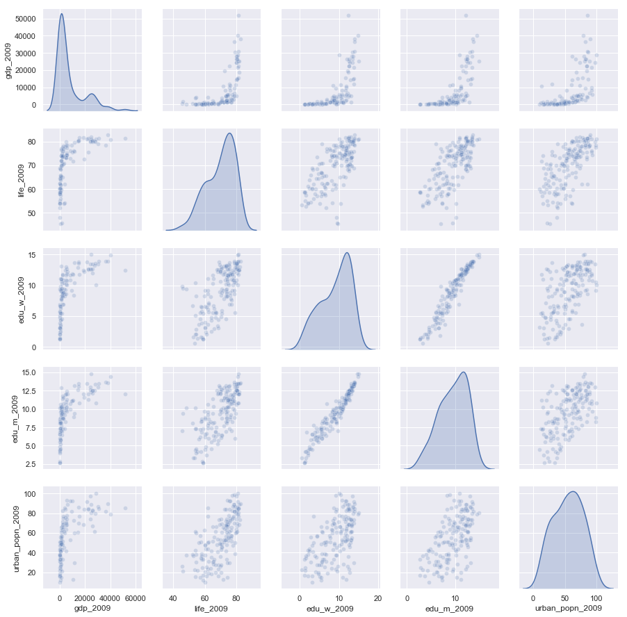

```python
sns.pairplot(df_combined_09, vars=['gdp_2009', 'life_2009', 'edu_w_2009', 'edu_m_2009', 'urban_popn_2009'],
             diag_kind='kde', plot_kws={'alpha': 0.2});
```

Set default display parameter for plots.

```python
plt.rcParams['figure.figsize'] = (8, 5)
```

**Question \#1**

### How have Mean years in school for women changed over time?

Back to Exploratory Data Analysis

To see how the Mean years in school, or education for women has changed over time, the entire dataset is plotted: all countries over all years. Before calling the plot function the dataframe is first transposed using the local `my.transpose_df()` function which transposes the dataframe and then shifts the country names from the first row to the column indexes.

```python
df_edu_w = pd.read_csv('school_years_women_clean.csv')
df_edu_w_T = my.transpose_df(df_edu_w, 'country')
df_edu_w_T.head(1)
```

| Country | Afghanistan | Albania | Algeria | Angola | Antigua and Barbuda | Argentina | Armenia | Australia | Austria | Azerbaijan | ... | United States | Uruguay | Uzbekistan | Vanuatu | Venezuela | Vietnam | West Bank and Gaza | Yemen, Rep. | Zambia | Zimbabwe |
| --- | --- | --- | --- | --- | --- | --- | --- | --- | --- | --- | --- | --- | --- | --- | --- | --- | --- | --- | --- | --- | --- |
| 1974 | 0.1 | 6.6 | 1.8 | 1.2 | 8.9 | 7.5 | 8.2 | 10.0 | 8.5 | 6.9 | ... | 12.4 | 7.3 | 7.2 | 3.0 | 5.0 | 5.0 | 3.8 | 0.1 | 2.9 | 3.2 |

1 rows × 175 columns

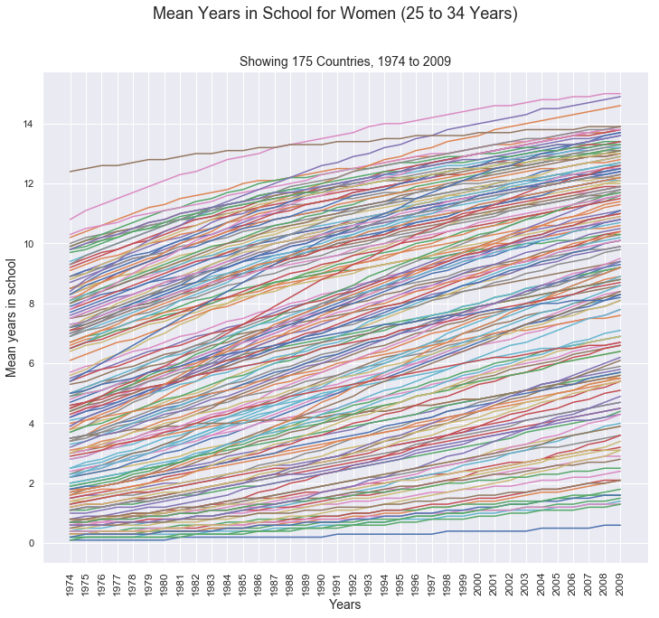

```python
df_plot = df_edu_w_T

labels_x = df_plot.index  # xtick labels
locations = np.arange(0, len(labels_x))  # xtick locations
n_countries = df_plot.shape[1]

plt.figure(figsize=(12,10))
plt.plot(labels_x, df_plot)

# title and labels
plt.suptitle("Mean Years in School for Women (25 to 34 Years)", fontsize=18)
str_title = "Showing " + str(n_countries) + " Countries, 1974 to 2009"
plt.title(str_title, fontsize=14)
plt.xlabel('Years',  fontsize=14)
plt.ylabel('Mean years in school',  fontsize=14)
plt.xticks(locations, labels_x, rotation='vertical',  fontsize=12)

plt.show()
```

The mass of plots shows a steady upward trend in the Mean years of school for women aged 25 to 34, and it looks like this is the case for all countries; it is messy, somewhat art-like, but a wonderful sight nonetheless! The first and last years, 1974 and 2009, were selected from the dataset to see how much schooling for women has increased over the 35 year span.

```python
df_edu_w_74_09 = df_edu_w[['1974', '2009']].copy()
df_edu_w_74_09['diff'] = df_edu_w_74_09['2009'] - df_edu_w_74_09['1974']
df_edu_w_74_09.describe()
```

|  | 1974 | 2009 | diff |
| --- | --- | --- | --- |
| count | 175.000000 | 175.000000 | 175.000000 |
| mean | 4.554857 | 9.111429 | 4.556571 |
| std | 3.146238 | 3.775828 | 1.573177 |
| min | 0.100000 | 0.600000 | 0.500000 |
| 25% | 1.700000 | 6.000000 | 3.600000 |
| 50% | 4.200000 | 10.100000 | 4.600000 |
| 75% | 7.250000 | 12.350000 | 5.600000 |
| max | 12.400000 | 15.000000 | 8.300000 |

Descriptive statistics for these two years:

- The count shows there is data for 175 countries
- The mean increased from an average of 4.5 years to 9.1 years (average of an average)
- The standard deviation in 2009 is slightly larger reflecting the higher max value for that year (more dispersed)
- Increased values at all quantile levels
- The distribution of differences, the 'diff' column, appears to be fairly normal:
  - mean and median are the same,
  - the 25th and 75th quantiles are equidistant

A distribution plot of all countries for 1974 and 2009 shows the differences. This plot uses 15 bins for years, the max value for 2009.

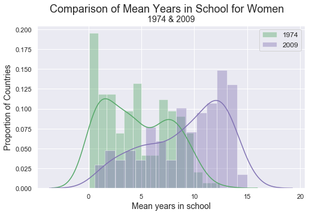

```python
df_plot = df_edu_w

sns.distplot(df_plot['1974'], norm_hist=False, label='1974', bins=15, color='g')
sns.distplot(df_plot['2009'], norm_hist=False, label='2009', bins=15, color='m')

plt.ylabel('Proportion of Countries', fontsize=14)
plt.xlabel('Mean years in school', fontsize=14)
plt.suptitle('Comparison of Mean Years in School for Women', fontsize=18)
plt.title('1974 & 2009', fontsize=14)
plt.legend(fontsize=12);
```

*Note: From https://github.com/mwaskom/seaborn/issues/1392, this error has been fixed but is not in a stable release yet.*

The distribution plots for 1974 (green) and 2009 (magenta) both appear to be somewhat bimodal and are also both skewed, although in opposite directions. There is a definite shift to the right seen in the 2009 plot in the Mean years of school for women in this age range, strongly suggesting that women were receiving more schooling in 2009 than in 1974.

**Question \#2**

### How does Mean years in school for women compare to that for men?

Back to Exploratory Data Analysis

To give a little perspective, this question follows on from the first; how does Mean years in school for women compare to that for men in the same age range? A copy of the combined dataframe is used and the `edu_` columns extracted, containing the data for Mean years in school for both men and women. A new `diff_edu_2009` column is created with the differences calculated.

```python
df_combined_09 = pd.read_csv('combined_09.csv')

df_edu_w_m_09 = df_combined_09[['Country', 'edu_w_2009', 'edu_m_2009']].copy()
df_edu_w_m_09['diff_edu_2009'] = df_edu_w_m_09['edu_w_2009'] - df_edu_w_m_09['edu_m_2009']
df_edu_w_m_09.describe()
```

|  | edu_w_2009 | edu_m_2009 | diff_edu_2009 |
| --- | --- | --- | --- |
| count | 175.000000 | 175.000000 | 175.000000 |
| mean | 9.111429 | 9.568571 | -0.457143 |
| std | 3.775828 | 2.876038 | 1.276644 |
| min | 0.600000 | 2.700000 | -5.000000 |
| 25% | 6.000000 | 7.300000 | -1.400000 |
| 50% | 10.100000 | 10.000000 | 0.000000 |
| 75% | 12.350000 | 12.100000 | 0.400000 |
| max | 15.000000 | 14.800000 | 2.800000 |

```python
df_edu_w_m_09['edu_w_2009'].corr(df_edu_w_m_09['edu_m_2009'])
```

```
0.9622357510478701
```

Descriptive statistics for the 2009 Mean years in school reflects the differences:

- the standard deviation is less for men, indicating less dispersion and reflected in the minimum and maximums
- the minimum average for women 2.1 years less than for men
- the lowest difference among countries is 5 years less for the women's average compared to that for men
- the highest difference among countries is 2.8 years higher for women on average compared to men
- the medians for both men and women are essentially the same
- the 25th percentile for men is closer to the median than that for women
- the upper 50th percentile for women appear to have slightly more years on average in school

The correlation coefficient is very high at 0.96, indicating a very strong association between the two.

Plotting the distributions for both men and women shows the extent of the differrences, that the distribution pertaining to men (cyan) is less dispersed and less skewed than that for the women (magenta).

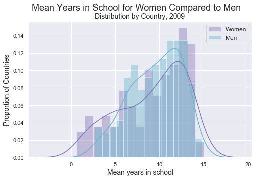

```python
sns.distplot(df_edu_w_m_09['edu_w_2009'], norm_hist=False, label='Women', bins=15, color='m')
sns.distplot(df_edu_w_m_09['edu_m_2009'], norm_hist=False, label='Men', bins=15, color='c')

plt.ylabel('Proportion of Countries', fontsize=14)
plt.xlabel('Mean years in school', fontsize=14)
plt.suptitle('Mean Years in School for Women Compared to Men', fontsize=18)
plt.title('Distribution by Country, 2009', fontsize=14)
plt.legend(fontsize=12);
```

*Note: From https://github.com/mwaskom/seaborn/issues/1392, this UserWarning has been fixed but is not in a stable release yet.*

Similar comparisons are made for the 1974 dataset, with a newly created `diff_edu_1974` column with differences calculated.

```python
df_combined_74 = pd.read_csv('combined_74.csv')

df_edu_w_m_74 = df_combined_74[['Country', 'edu_w_1974', 'edu_m_1974']].copy()
df_edu_w_m_74['diff_edu_1974'] = df_edu_w_m_74['edu_w_1974'] - df_edu_w_m_74['edu_m_1974']
df_edu_w_m_74.info()
```

```
<class 'pandas.core.frame.DataFrame'>
RangeIndex: 175 entries, 0 to 174
Data columns (total 4 columns):
Country          175 non-null object
edu_w_1974       175 non-null float64
edu_m_1974       175 non-null float64
diff_edu_1974    175 non-null float64
dtypes: float64(3), object(1)
memory usage: 5.5+ KB
```

```python
df_edu_w_m_74.describe()
```

|  | edu_w_1974 | edu_m_1974 | diff_edu_1974 |
| --- | --- | --- | --- |
| count | 175.000000 | 175.000000 | 175.000000 |
| mean | 4.554857 | 5.692000 | -1.137143 |
| std | 3.146238 | 2.784841 | 0.891816 |
| min | 0.100000 | 0.500000 | -4.100000 |
| 25% | 1.700000 | 3.350000 | -1.700000 |
| 50% | 4.200000 | 5.500000 | -1.100000 |
| 75% | 7.250000 | 8.050000 | -0.500000 |
| max | 12.400000 | 12.800000 | 1.100000 |

As for the 2009 data, the correlation coefficient of 0.96 is very high.

```python
df_edu_w_m_74['edu_w_1974'].corr(df_edu_w_m_74['edu_m_1974'])
```

```
0.9620665309500163
```

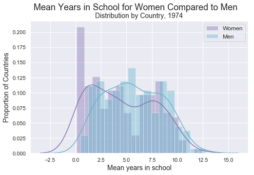

```python
sns.distplot(df_edu_w_m_74['edu_w_1974'], norm_hist=False, label='Women', bins=16, color='m')
sns.distplot(df_edu_w_m_74['edu_m_1974'], norm_hist=False, label='Men', bins=16, color='c')

plt.ylabel('Proportion of Countries', fontsize=14)
plt.xlabel('Mean years in school', fontsize=14)
plt.suptitle('Mean Years in School for Women Compared to Men', fontsize=18)
plt.title('Distribution by Country, 1974', fontsize=14)
plt.legend(fontsize=12);
```

Plotting the 1974 distributions for both men and women shows their differrences: the distribution pertaining to men (cyan) is slightly less dispersed and but appears more normal than that for the women (magenta).

The differences appear to be more varied in the 2009 data than with the 1974.

**Question \#3**

### What region has seen Mean years in school for women increase the most?

Back to Exploratory Data Analysis

To see which region has seen the most increase in Mean years in school for women, the data for this indicator from 1974 and 2009 is extracted from the combined datasets. The dataframe is checked before the plot is created and the differences in regional means are calculated.

```python
df_combined_74 = pd.read_csv('combined_74.csv')
df_combined_09 = pd.read_csv('combined_09.csv')

df_edu_w_reg_09 = df_combined_09[['Country', 'edu_w_2009']].copy()
df_edu_w_reg_74_09 = df_combined_74[['Country', 'region', 'edu_w_1974']].copy()
df_edu_w_reg_74_09 = pd.merge(df_edu_w_reg_74_09, df_edu_w_reg_09, on='Country', how='inner')

df_edu_w_reg_74_09.info()
```

```
<class 'pandas.core.frame.DataFrame'>
Int64Index: 175 entries, 0 to 174
Data columns (total 4 columns):
Country       175 non-null object
region        175 non-null object
edu_w_1974    175 non-null float64
edu_w_2009    175 non-null float64
dtypes: float64(2), object(2)
memory usage: 6.8+ KB
```

```python
df2_region_means = df_edu_w_reg_74_09.groupby(['region']).mean()
df2_region_means['change_edu_w'] = df2_region_means['edu_w_2009'] - df2_region_means['edu_w_1974']
df2_region_means.nlargest(len(df2_region_means), 'change_edu_w')
```

| region | edu_w_1974 | edu_w_2009 | change_edu_w |
| --- | --- | --- | --- |
| america_south | 5.116667 | 10.341667 | 5.225000 |
| asia_west | 3.711538 | 8.792308 | 5.080769 |
| east_asia_pacific | 4.848000 | 9.784000 | 4.936000 |
| europe_west | 8.033333 | 12.883333 | 4.850000 |
| europe_east | 7.704167 | 12.408333 | 4.704167 |
| africa_north | 1.360000 | 6.060000 | 4.700000 |
| america_north | 5.966667 | 10.483333 | 4.516667 |
| africa_sub_saharan | 1.580851 | 5.287234 | 3.706383 |

The calculated column 'change', with the differences between 1974 and 2009, indicates that all regions display an increase in Mean years in school for women aged 25 to 34 years, and the region for South America the most.

*Note: The following plot code was adapted from the post at http://cmdlinetips.com/2018/03/how-to-make-boxplots-in-python-with-pandas-and-seaborn/*

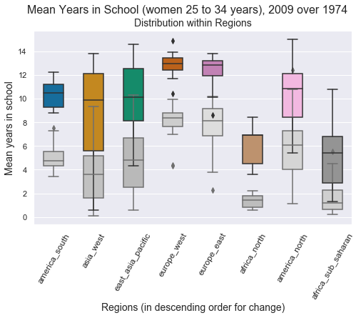

```python
df_plot = df_edu_w_reg_74_09

bplot = sns.boxplot(y='edu_w_1974', x='region',
                    data=df_plot,
                    width=0.5,
                    palette="pastel",
                    saturation=0,
                    order=df2_region_means.nlargest(len(df2_region_means),'change_edu_w').index.tolist())
bplot = sns.boxplot(y='edu_w_2009', x='region',
                    data=df_plot,
                    width=0.5,
                    palette="colorblind",
                    order=df2_region_means.nlargest(len(df2_region_means),'change_edu_w').index.tolist())

# title and labels
plt.suptitle('Mean Years in School (women 25 to 34 years), 2009 over 1974', fontsize=16)
plt.title('Distribution within Regions', fontsize=14)
plt.xlabel("Regions (in descending order for change)",  fontsize=14)
plt.ylabel('Mean years in school',  fontsize=14)
plt.xticks(rotation=60,  fontsize=12)
plt.show()
```

The boxplot gives a good visual with 1974 data in greys and the 2009 data in colours. It shows how differently the regions are distributed but how all regions have seen marked increases. Some regions have seen such marked increases the minimum for 2009 is higher than the maximum for 1974, as in the case of South America.

```python
df_edu_w_reg_74_09.groupby(['region']).describe()
```

| region | edu_w_1974 count | edu_w_1974 mean | edu_w_1974 std | edu_w_1974 min | edu_w_1974 25% | edu_w_1974 50% | edu_w_1974 75% | edu_w_1974 max | edu_w_2009 count | edu_w_2009 mean | edu_w_2009 std | edu_w_2009 min | edu_w_2009 25% | edu_w_2009 50% | edu_w_2009 75% | edu_w_2009 max |
| --- | --- | --- | --- | --- | --- | --- | --- | --- | --- | --- | --- | --- | --- | --- | --- | --- |
| africa_north | 5.0 | 1.360000 | 0.669328 | 0.6 | 0.800 | 1.40 | 1.800 | 2.2 | 5.0 | 6.060000 | 1.960357 | 3.6 | 4.500 | 6.90 | 6.900 | 8.4 |
| africa_sub_saharan | 47.0 | 1.580851 | 1.288686 | 0.2 | 0.650 | 1.20 | 2.250 | 5.5 | 47.0 | 5.287234 | 2.862016 | 1.3 | 2.850 | 5.40 | 6.800 | 10.8 |
| america_north | 18.0 | 5.966667 | 2.963900 | 1.1 | 4.050 | 6.05 | 7.250 | 12.4 | 18.0 | 10.483333 | 2.683775 | 5.4 | 8.425 | 10.85 | 12.125 | 15.0 |
| america_south | 12.0 | 5.116667 | 1.433897 | 3.4 | 4.325 | 4.75 | 5.550 | 7.5 | 12.0 | 10.341667 | 1.221369 | 8.8 | 9.275 | 10.50 | 11.225 | 12.2 |
| asia_west | 26.0 | 3.711538 | 2.671228 | 0.1 | 1.625 | 3.60 | 5.175 | 9.3 | 26.0 | 8.792308 | 3.775386 | 0.6 | 5.600 | 9.85 | 12.100 | 13.8 |
| east_asia_pacific | 25.0 | 4.848000 | 2.757432 | 0.6 | 2.500 | 4.80 | 6.700 | 10.3 | 25.0 | 9.784000 | 3.071737 | 4.3 | 8.100 | 10.10 | 12.500 | 14.6 |
| europe_east | 24.0 | 7.704167 | 1.941644 | 2.3 | 6.825 | 8.10 | 9.125 | 10.2 | 24.0 | 12.408333 | 1.212226 | 8.6 | 11.900 | 12.85 | 13.200 | 13.8 |
| europe_west | 18.0 | 8.033333 | 1.568064 | 4.3 | 7.625 | 8.35 | 8.775 | 9.9 | 18.0 | 12.883333 | 0.976940 | 10.4 | 12.425 | 12.95 | 13.400 | 14.9 |

The descriptive statistics shown above provide a very good picture of what the boxplot shows visually, with additional information such as the count of countries and standard deviation within regions. As on the plot above, the differences between the 1974 max and the 2009 min values are simple to see: from the data, South America as a region has seen the greatest increase in Mean years in school for women.

**Question #4**

### Which countries have seen the greatest increase in Mean years in school for women?

Back to Exploratory Data Analysis

To get a closer look at the countries with the greatest increase, the dataframes containing data for 1974 and 2009 (created previously at the beginning of the EDA section above) are merged, and a new column added with the calculated difference between years. The top 20 countries with the greatest change are displayed below, and descriptive statistics from the whole dataframe with which to compare.

```python
df_combined_74 = pd.read_csv('combined_74.csv')
df_combined_09 = pd.read_csv('combined_09.csv')

df_edu_w_reg_09 = df_combined_09[['Country', 'edu_w_2009']].copy()
df_edu_w_reg_74_09 = df_combined_74[['Country', 'region', 'edu_w_1974']].copy()

df_edu_w_reg_74_09 = pd.merge(df_edu_w_reg_74_09, df_edu_w_reg_09, on='Country', how='inner')
df_edu_w_reg_74_09.info()
```

```
<class 'pandas.core.frame.DataFrame'>
Int64Index: 175 entries, 0 to 174
Data columns (total 4 columns):
Country       175 non-null object
region        175 non-null object
edu_w_1974    175 non-null float64
edu_w_2009    175 non-null float64
dtypes: float64(2), object(2)
memory usage: 6.8+ KB
```

The merge looks successful, there are 175 entries for all columns. A new column with the differences is added.

```python
df_edu_w_reg_74_09['change_edu_w'] = df_edu_w_reg_74_09['edu_w_2009'] - df_edu_w_reg_74_09['edu_w_1974']
top_20_change = df_edu_w_reg_74_09.nlargest(20, 'change_edu_w')
top_20_change.reset_index(drop=True, inplace=True)
top_20_change
```

|  | Country | region | edu_w_1974 | edu_w_2009 | change_edu_w |
| --- | --- | --- | --- | --- | --- |
| 0 | Taiwan | east_asia_pacific | 5.4 | 13.7 | 8.3 |
| 1 | Jordan | asia_west | 3.7 | 11.8 | 8.1 |
| 2 | United Arab Emirates | asia_west | 4.5 | 12.6 | 8.1 |
| 3 | Bahrain | asia_west | 3.4 | 11.4 | 8.0 |
| 4 | Malaysia | east_asia_pacific | 3.9 | 11.6 | 7.7 |
| 5 | West Bank and Gaza | asia_west | 3.8 | 11.3 | 7.5 |
| 6 | Saudi Arabia | asia_west | 1.7 | 9.2 | 7.5 |
| 7 | Spain | europe_west | 4.4 | 11.7 | 7.3 |
| 8 | Kenya | africa_sub_saharan | 2.2 | 9.2 | 7.0 |
| 9 | Mauritius | africa_sub_saharan | 3.3 | 10.2 | 6.9 |
| 10 | Oman | asia_west | 1.6 | 8.4 | 6.8 |
| 11 | Lebanon | asia_west | 4.2 | 10.9 | 6.7 |
| 12 | Swaziland | africa_sub_saharan | 2.8 | 9.5 | 6.7 |
| 13 | Qatar | asia_west | 3.9 | 10.5 | 6.6 |
| 14 | Croatia | europe_east | 5.6 | 12.1 | 6.5 |
| 15 | Guyana | america_south | 4.6 | 11.1 | 6.5 |
| 16 | Korea, Rep. | east_asia_pacific | 8.1 | 14.6 | 6.5 |
| 17 | Norway | europe_west | 8.4 | 14.9 | 6.5 |
| 18 | Indonesia | east_asia_pacific | 2.5 | 8.9 | 6.4 |
| 19 | Slovak Republic | europe_east | 6.9 | 13.3 | 6.4 |

The following list shows the eight regions with the count of all countries within:

```python
df_regions.groupby(['region']).size()
```

```
region
africa_north           5
africa_sub_saharan    47
america_north         18
america_south         12
asia_west             26
east_asia_pacific     25
europe_east           24
europe_west           18
dtype: int64
```

This list sorts the top 20 countries and shows the total count by region:

```python
top_20_change.groupby(['region']).size()
```

```
region
africa_sub_saharan    3
america_south         1
asia_west             8
east_asia_pacific     4
europe_east           2
europe_west           2
dtype: int64
```

Using the last two lists to calculate the proportion of the top 20 countries within their region:

```python
top_20_regional_proportion = top_20_change.groupby(['region']).size() * 100 / df_regions.groupby(['region']).size()
top_20_regional_proportion
```

```
region
africa_north                NaN
africa_sub_saharan     6.382979
america_north               NaN
america_south          8.333333
asia_west             30.769231
east_asia_pacific     16.000000
europe_east            8.333333
europe_west           11.111111
dtype: float64
```

The bar chart plots the figures from the list above, it shows the percentage within the region, of the top 20 countries: for example the 8 of the top 20 countries fall within the Asia West region, of which these countries make up a 30% proportion of the region.

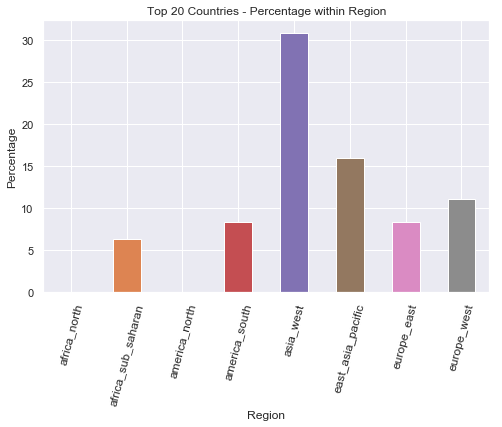

```python
top_20_regional_proportion.plot(kind='bar');

plt.ylabel('Percentage', fontsize=12)
plt.xlabel('Region', fontsize=12)
plt.title('Top 20 Countries - Percentage within Region', fontsize=12)
plt.xticks(rotation=75,  fontsize=12)
plt.show();
```

Descriptive statistics for the top 20 countries only:

```python
top_20_change.describe()
```

|  | edu_w_1974 | edu_w_2009 | change_edu_w |
| --- | --- | --- | --- |
| count | 20.000000 | 20.000000 | 20.000000 |
| mean | 4.245000 | 11.345000 | 7.100000 |
| std | 1.887486 | 1.845186 | 0.652929 |
| min | 1.600000 | 8.400000 | 6.400000 |
| 25% | 3.175000 | 10.025000 | 6.500000 |
| 50% | 3.900000 | 11.350000 | 6.850000 |
| 75% | 4.800000 | 12.225000 | 7.550000 |
| max | 8.400000 | 14.900000 | 8.300000 |

Descriptive statistics for the entire dataset:

```python
df_edu_w_reg_74_09.describe()
```

|  | edu_w_1974 | edu_w_2009 | change_edu_w |
| --- | --- | --- | --- |
| count | 175.000000 | 175.000000 | 175.000000 |
| mean | 4.554857 | 9.111429 | 4.556571 |
| std | 3.146238 | 3.775828 | 1.573177 |
| min | 0.100000 | 0.600000 | 0.500000 |
| 25% | 1.700000 | 6.000000 | 3.600000 |
| 50% | 4.200000 | 10.100000 | 4.600000 |
| 75% | 7.250000 | 12.350000 | 5.600000 |
| max | 12.400000 | 15.000000 | 8.300000 |

To summarize the statistics:

- From the table with the rankings, above, Taiwan tops the list with an increase of 8.3 years in Mean years in school for women
- Jordan, the UAE and Bahrain are close behind Taiwan, all with increases over 8.0
- The rest of the top 20 countries all show increases of more than 6.4 years in the Mean years in school
- These top 20 countries are all in the upper 75th percentile of the entire set
- The top 20 countries, from the top 20 statistics, have an average increase in Mean years in school of 7.1 years
- The 7.1 mean is greater than the 6.9 median, 50th quantile
- The standard deviation is quite small indicating a tight distribution

**Question #5**

### What variables are associated with the countries that have seen the greatest increase in Mean years in school for women?

Back to Exploratory Data Analysis

This question is possibly the most tentative, to see if it is possible to find a variable that may be associated with the top 20 countries that have seen the greatest increase in Mean years in school for women, when compared to the rest of the countries. Two filtered datasets are created from the combined datasets for 1974 and 2009, one with the top 20 countries and the other containing the rest of the countries.

```python
df_combined_74 = pd.read_csv('combined_74.csv')
df_combined_09 = pd.read_csv('combined_09.csv')

df_74 = df_combined_74[['Country', 'edu_w_1974', 'edu_m_1974', 'gdp_1974', 'life_1974', 'urban_popn_1974']].copy()
df_09 = df_combined_09[['Country', 'edu_w_2009', 'edu_m_2009', 'gdp_2009', 'life_2009', 'urban_popn_2009']].copy()

df_all = pd.merge(df_74, df_09, on='Country', how='inner')
df_all.info()
```

```
<class 'pandas.core.frame.DataFrame'>
Int64Index: 175 entries, 0 to 174
Data columns (total 11 columns):
Country            175 non-null object
edu_w_1974         175 non-null float64
edu_m_1974         175 non-null float64
gdp_1974           108 non-null float64
life_1974          166 non-null float64
urban_popn_1974    166 non-null float64
edu_w_2009         175 non-null float64
edu_m_2009         175 non-null float64
gdp_2009           108 non-null float64
life_2009          166 non-null float64
urban_popn_2009    166 non-null float64
dtypes: float64(10), object(1)
memory usage: 16.4+ KB
```

There is quite a lot of missing data for GDP, but only 9 data points missing for Life expectancy and Urban population. For the purposes of this question, the dataset will remain as is. The plots involving these indicators ignores NaNs, according to Matplotlib documentation, and plots nothing for the associated coordinates.

New columns are created for the calculated differences (changes) from 1974 to 2009 for each variable (indicator).

```python
df_all['change_edu_w'] = df_all['edu_w_2009'] - df_all['edu_w_1974']
df_all['change_edu_m'] = df_all['edu_m_2009'] - df_all['edu_m_1974']
df_all['change_gdp'] = df_all['gdp_2009'] - df_all['gdp_1974']
df_all['change_life'] = df_all['life_2009'] - df_all['life_1974']
df_all['change_urban_popn'] = df_all['urban_popn_2009'] - df_all['urban_popn_1974']
df_all.info()
```

```
<class 'pandas.core.frame.DataFrame'>
Int64Index: 175 entries, 0 to 174
Data columns (total 16 columns):
Country              175 non-null object
edu_w_1974           175 non-null float64
edu_m_1974           175 non-null float64
gdp_1974             108 non-null float64
life_1974            166 non-null float64
urban_popn_1974      166 non-null float64
edu_w_2009           175 non-null float64
edu_m_2009           175 non-null float64
gdp_2009             108 non-null float64
life_2009            166 non-null float64
urban_popn_2009      166 non-null float64
change_edu_w         175 non-null float64
change_edu_m         175 non-null float64
change_gdp           108 non-null float64
change_life          166 non-null float64
change_urban_popn    166 non-null float64
dtypes: float64(15), object(1)
memory usage: 23.2+ KB
```

The dataframe now contains all the data and also all the differences or changes from 1974 to 2009.

The countries from the top 20 list in the previous question are now removed and saved to a separate dataframe.

```python
top_20_list = top_20_change['Country'].tolist()
top_20_list
```

```
['Taiwan',
 'Jordan',
 'United Arab Emirates',
 'Bahrain',
 'Malaysia',
 'West Bank and Gaza',
 'Saudi Arabia',
 'Spain',
 'Kenya',
 'Mauritius',
 'Oman',
 'Lebanon',
 'Swaziland',
 'Qatar',
 'Croatia',
 'Guyana',
 'Korea, Rep.',
 'Norway',
 'Indonesia',
 'Slovak Republic']
```

```python
query_str = "Country in " + str(top_20_list)
top_20_list_74_09 = df_all.query(query_str)
top_20_list_74_09.nlargest(20, columns='change_edu_w').head()
```

|  | Country | edu_w_1974 | edu_m_1974 | gdp_1974 | life_1974 | urban_popn_1974 | edu_w_2009 | edu_m_2009 | gdp_2009 | life_2009 | urban_popn_2009 | change_edu_w | change_edu_m | change_gdp | change_life | change_urban_popn |
| --- | --- | --- | --- | --- | --- | --- | --- | --- | --- | --- | --- | --- | --- | --- | --- | --- |
| 150 | Taiwan | 5.4 | 7.3 | NaN | 69.80 | NaN | 13.7 | 13.4 | NaN | 78.7 | NaN | 8.3 | 6.1 | NaN | 8.90 | NaN |
| 77 | Jordan | 3.7 | 6.8 | 1118.724641 | 63.98 | 57.3142 | 11.8 | 11.8 | 2577.480413 | 77.5 | 82.2138 | 8.1 | 5.0 | 1458.755772 | 13.52 | 24.8996 |
| 163 | United Arab Emirates | 4.5 | 5.6 | 56037.960278 | 63.70 | 79.2322 | 12.6 | 11.3 | 22507.001570 | 75.6 | 83.6860 | 8.1 | 5.7 | -33530.958708 | 11.90 | 4.4538 |
| 11 | Bahrain | 3.4 | 4.9 | NaN | 66.03 | 84.7350 | 11.4 | 10.8 | NaN | 78.2 | 88.5782 | 8.0 | 5.9 | NaN | 12.17 | 3.8432 |
| 94 | Malaysia | 3.9 | 6.0 | 1446.402359 | 66.73 | 36.8124 | 11.6 | 11.0 | 4901.547097 | 74.3 | 71.1198 | 7.7 | 5.0 | 3455.144737 | 7.57 | 34.3074 |

Descriptive statistics for the top 20 countries that had the greatest increase in Mean years in school for women.

```python
top_20_list_74_09.describe()
```

|  | edu_w_1974 | edu_m_1974 | gdp_1974 | life_1974 | urban_popn_1974 | edu_w_2009 | edu_m_2009 | gdp_2009 | life_2009 | urban_popn_2009 | change_edu_w | change_edu_m | change_gdp | change_life | change_urban_popn |
| --- | --- | --- | --- | --- | --- | --- | --- | --- | --- | --- | --- | --- | --- | --- | --- |
| count | 20.000000 | 20.000000 | 12.000000 | 19.000000 | 18.000000 | 20.000000 | 20.000000 | 12.000000 | 19.000000 | 18.000000 | 20.000000 | 20.000000 | 12.000000 | 19.000000 | 18.000000 |
| mean | 4.245000 | 6.070000 | 8936.900359 | 64.294737 | 50.394544 | 11.345000 | 11.105000 | 9641.463615 | 73.631579 | 65.106078 | 7.100000 | 5.035000 | 704.563257 | 9.336842 | 14.711533 |
| std | 1.887486 | 1.778556 | 15972.440227 | 6.364146 | 23.320613 | 1.845186 | 1.711409 | 11760.058643 | 8.346793 | 23.693820 | 0.652929 | 0.633516 | 12786.471488 | 5.510572 | 11.557690 |
| min | 1.600000 | 3.500000 | 289.129702 | 51.300000 | 12.390200 | 8.400000 | 8.800000 | 456.771543 | 45.900000 | 21.436000 | 6.400000 | 3.800000 | -33530.958708 | -5.400000 | -1.548200 |
| 25% | 3.175000 | 4.825000 | 775.114942 | 60.755000 | 36.580650 | 10.025000 | 9.975000 | 1637.522975 | 73.500000 | 50.589900 | 6.500000 | 4.650000 | 288.392337 | 6.345000 | 8.294800 |
| 50% | 3.900000 | 5.700000 | 1536.836273 | 63.990000 | 50.815000 | 11.350000 | 10.900000 | 4949.968578 | 76.200000 | 73.425200 | 6.850000 | 5.000000 | 1273.060947 | 8.900000 | 10.976200 |
| 75% | 4.800000 | 6.925000 | 10101.535848 | 69.715000 | 67.090950 | 12.225000 | 11.575000 | 12274.609016 | 78.350000 | 82.126100 | 7.550000 | 5.550000 | 4355.664829 | 12.470000 | 24.061050 |
| max | 8.400000 | 10.300000 | 56037.960278 | 74.880000 | 88.803600 | 14.900000 | 14.800000 | 40199.346223 | 81.500000 | 98.413800 | 8.300000 | 6.100000 | 22731.153664 | 19.090000 | 36.428400 |

The descriptive statistics for the changes from 1974 to 2009 for the top 20 countries show the Mean years in school has increased more for women than for men in all percentile ranges.

Next, the comparison dataframe is created with the top 20 countries filtered out. These two dataframes are used for making the comparisons.

```python
query_str = "Country not in " + str(top_20_list)
not_top_20_list_74_09 = df_all.query(query_str)
not_top_20_list_74_09.head()
```

|  | Country | edu_w_1974 | edu_m_1974 | gdp_1974 | life_1974 | urban_popn_1974 | edu_w_2009 | edu_m_2009 | gdp_2009 | life_2009 | urban_popn_2009 | change_edu_w | change_edu_m | change_gdp | change_life | change_urban_popn |
| --- | --- | --- | --- | --- | --- | --- | --- | --- | --- | --- | --- | --- | --- | --- | --- | --- |
| 0 | Afghanistan | 0.1 | 1.3 | NaN | 39.14 | 12.8286 | 0.6 | 3.3 | NaN | 53.3 | 22.9676 | 0.5 | 2.0 | NaN | 14.16 | 10.1390 |
| 1 | Albania | 6.6 | 7.2 | NaN | 69.35 | 32.5176 | 11.0 | 11.0 | NaN | 77.0 | 51.2184 | 4.4 | 3.8 | NaN | 7.65 | 18.7008 |
| 2 | Algeria | 1.8 | 2.3 | 1603.349620 | 54.52 | 40.1640 | 6.9 | 7.3 | 2192.703976 | 75.7 | 70.9570 | 5.1 | 5.0 | 589.354356 | 21.18 | 30.7930 |
| 3 | Angola | 1.2 | 2.8 | NaN | 43.71 | 18.2938 | 4.5 | 6.2 | NaN | 57.1 | 57.4918 | 3.3 | 3.4 | NaN | 13.39 | 39.1980 |
| 4 | Antigua and Barbuda | 8.9 | 8.7 | 3815.953695 | 68.64 | 34.1374 | 13.7 | 13.2 | 11645.634909 | 75.7 | 30.0322 | 4.8 | 4.5 | 7829.681214 | 7.06 | -4.1052 |

A check shows that the top 20 countries are no longer in the dataframe.

```python
print(query_str, "?  = ", not_top_20_list_74_09.query(query_str).any().any())
```

```
Country not in ['Taiwan', 'Jordan', 'United Arab Emirates', 'Bahrain', 'Malaysia', 'West Bank and Gaza', 'Saudi Arabia', 'Spain', 'Kenya', 'Mauritius', 'Oman', 'Lebanon', 'Swaziland', 'Qatar', 'Croatia', 'Guyana', 'Korea, Rep.', 'Norway', 'Indonesia', 'Slovak Republic'] ?  =  True
```

```python
not_top_20_list_74_09.info()
```

```
<class 'pandas.core.frame.DataFrame'>
Int64Index: 155 entries, 0 to 174
Data columns (total 16 columns):
Country              155 non-null object
edu_w_1974           155 non-null float64
edu_m_1974           155 non-null float64
gdp_1974             96 non-null float64
life_1974            147 non-null float64
urban_popn_1974      148 non-null float64
edu_w_2009           155 non-null float64
edu_m_2009           155 non-null float64
gdp_2009             96 non-null float64
life_2009            147 non-null float64
urban_popn_2009      148 non-null float64
change_edu_w         155 non-null float64
change_edu_m         155 non-null float64
change_gdp           96 non-null float64
change_life          147 non-null float64
change_urban_popn    148 non-null float64
dtypes: float64(15), object(1)
memory usage: 20.6+ KB
```

The results from `info()` above show the counts are 20 less than the original combined dataframe, this confirms the countries have been removed.

```python
not_top_20_list_74_09.describe()
```

|  | edu_w_1974 | edu_m_1974 | gdp_1974 | life_1974 | urban_popn_1974 | edu_w_2009 | edu_m_2009 | gdp_2009 | life_2009 | urban_popn_2009 | change_edu_w | change_edu_m | change_gdp | change_life | change_urban_popn |
| --- | --- | --- | --- | --- | --- | --- | --- | --- | --- | --- | --- | --- | --- | --- | --- |
| count | 155.000000 | 155.000000 | 96.000000 | 147.000000 | 148.000000 | 155.000000 | 155.000000 | 96.000000 | 147.000000 | 148.000000 | 155.000000 | 155.000000 | 96.000000 | 147.000000 | 148.000000 |
| mean | 4.594839 | 5.643226 | 4238.644540 | 59.785238 | 40.613699 | 8.823226 | 9.370323 | 7937.065705 | 69.513605 | 53.882736 | 4.228387 | 3.727097 | 3698.421165 | 9.728367 | 13.269038 |
| std | 3.275783 | 2.889862 | 5559.190294 | 10.618426 | 23.183311 | 3.867410 | 2.939104 | 11050.930257 | 8.764199 | 22.536976 | 1.339837 | 0.910424 | 5942.949802 | 6.553299 | 9.780652 |
| min | 0.100000 | 0.500000 | 136.263282 | 34.940000 | 3.050800 | 0.600000 | 2.700000 | 101.169007 | 45.500000 | 10.388600 | 0.500000 | 0.900000 | -1575.141848 | -10.920000 | -9.318200 |
| 25% | 1.450000 | 3.100000 | 507.326460 | 51.245000 | 20.863500 | 5.600000 | 7.000000 | 591.242694 | 62.200000 | 36.124250 | 3.600000 | 3.100000 | 87.417545 | 5.910000 | 7.048900 |
| 50% | 4.300000 | 5.300000 | 1638.916688 | 60.630000 | 40.274000 | 9.400000 | 9.700000 | 2387.526386 | 70.900000 | 53.564000 | 4.400000 | 3.700000 | 626.338813 | 8.220000 | 11.935800 |
| 75% | 7.500000 | 8.200000 | 5682.493507 | 69.585000 | 57.706850 | 12.350000 | 12.100000 | 10814.571542 | 76.300000 | 69.852750 | 5.200000 | 4.400000 | 5020.442755 | 13.770000 | 18.638100 |
| max | 12.400000 | 12.800000 | 20612.020614 | 74.940000 | 100.000000 | 15.000000 | 14.800000 | 51678.203120 | 82.700000 | 100.000000 | 6.400000 | 5.800000 | 31066.182506 | 31.660000 | 49.171600 |

Five double plots are created below, from the change columns for each of the variables, comparing the top 20 countries with the rest.

**Note:** The plot code produces a RuntimeWarning because of NaNs in the dataframe, explained here: https://github.com/numpy/numpy/issues/7503.

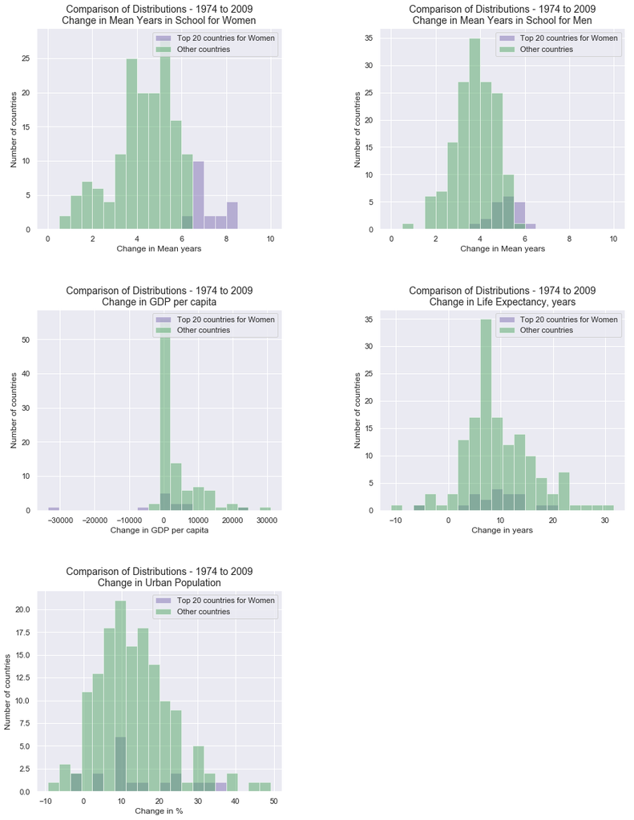

```python
df_top_20 = top_20_list_74_09
df_other = not_top_20_list_74_09

fig = plt.figure(figsize=(15, 20))
ax1 = fig.add_subplot(3, 2, 1)
ax2 = fig.add_subplot(3, 2, 2)
ax3 = fig.add_subplot(3, 2, 3)
ax4 = fig.add_subplot(3, 2, 4)
ax5 = fig.add_subplot(3, 2, 5)

fig.subplots_adjust(hspace=0.4, wspace=0.4)

x1_1 = df_top_20['change_edu_w']
x1_2 = df_other['change_edu_w']
ax1.hist(x1_1, bins=20, color='m', label='Top 20 countries for Women', alpha=0.5, range=(0,10))
ax1.hist(x1_2, bins=20, color='g', label='Other countries', alpha=0.5, range=(0,10))
ax1.set_title('Comparison of Distributions - 1974 to 2009\nChange in Mean Years in School for Women', fontsize=14)
ax1.set_xlabel('Change in Mean years', fontsize=12)
ax1.set_ylabel('Number of countries')
ax1.legend()

x2_1 = df_top_20['change_edu_m']
x2_2 = df_other['change_edu_m']
ax2.hist(x2_1, bins=20, color='m', label='Top 20 countries for Women', alpha=0.5, range=(0,10))
ax2.hist(x2_2, bins=20, color='g', label='Other countries', alpha=0.5, range=(0,10))
ax2.set_title('Comparison of Distributions - 1974 to 2009\nChange in Mean Years in School for Men', fontsize=14)
ax2.set_xlabel('Change in Mean years', fontsize=12)
ax2.set_ylabel('Number of countries')
ax2.legend()

x3_1 = df_top_20['change_gdp']
x3_2 = df_other['change_gdp']
min3 = min(df_top_20['change_gdp'].min(), df_other['change_gdp'].min())
max3 = max(df_top_20['change_gdp'].max(), df_other['change_gdp'].max())
ax3.hist(x3_1, bins=20, color='m', label='Top 20 countries for Women', alpha=0.5, range=(min3, max3))
ax3.hist(x3_2, bins=20, color='g', label='Other countries', alpha=0.5, range=(min3, max3))
ax3.set_title('Comparison of Distributions - 1974 to 2009\nChange in GDP per capita', fontsize=14)
ax3.set_xlabel('Change in GDP per capita', fontsize=12)
ax3.set_ylabel('Number of countries')
ax3.legend()

x4_1 = df_top_20['change_life']
x4_2 = df_other['change_life']
min4 = min(df_top_20['change_life'].min(), df_other['change_life'].min())
max4 = max(df_top_20['change_life'].max(), df_other['change_life'].max())
ax4.hist(x4_1, bins=20, color='m', label='Top 20 countries for Women', alpha=0.5, range=(min4, max4))
ax4.hist(x4_2, bins=20, color='g', label='Other countries', alpha=0.5, range=(min4, max4))
ax4.set_title('Comparison of Distributions - 1974 to 2009\nChange in Life Expectancy, years', fontsize=14)
ax4.set_xlabel('Change in years', fontsize=12)
ax4.set_ylabel('Number of countries')
ax4.legend()

x5_1 = df_top_20['change_urban_popn']
x5_2 = df_other['change_urban_popn']
min5 = min(df_top_20['change_urban_popn'].min(), df_other['change_urban_popn'].min())
max5 = max(df_top_20['change_urban_popn'].max(), df_other['change_urban_popn'].max())
ax5.hist(x5_1, bins=20, color='m', label='Top 20 countries for Women', alpha=0.5, range=(min5, max5))
ax5.hist(x5_2, bins=20, color='g', label='Other countries', alpha=0.5, range=(min5, max5))
ax5.set_title('Comparison of Distributions - 1974 to 2009\nChange in Urban Population', fontsize=14)
ax5.set_xlabel('Change in %', fontsize=12)
ax5.set_ylabel('Number of countries')
ax5.legend();
```

Four of the five plots above attempted to draw some answers from the comparisons of the top 20 countries having the greatest change in Mean years in school for women (differences between 1974 and 2009), with the rest of the countries. The visuals show that the distributions for the three variables - GDP per capita, Life expectancy and Urban population (% of total) - of the top 20 countries are somewhat similar in nature to the distributions for the rest of the countries, unlike the comparison for the Mean years in school for women. Given the sparseness of data, especially for the GDP per capita (only 108 data pionts), any associations with these three variables for the large increases in Mean years in school for the top 20 countries appears slim.

**Question #6**

### How does Mean years in school for women relate to Life expectancy and GDP?

Back to Exploratory Data Analysis

The scatter plots at the beginning of the EDA section showed that there may be an association between Mean years in school for women and Life expectancy, as well as with GDP per capita. Plotted all together the relationships are more interesting.

```python
df_combined_09 = pd.read_csv('combined_09.csv')

df_edu_w_life_gdp_09 = df_combined_09[['Country', 'edu_w_2009', 'life_2009', 'gdp_2009']].copy()
df_edu_w_life_gdp_09.dropna(how='any', inplace=True)
df_edu_w_life_gdp_09.describe()
```

|  | edu_w_2009 | life_2009 | gdp_2009 |
| --- | --- | --- | --- |
| count | 108.000000 | 108.000000 | 108.000000 |
| mean | 9.056481 | 70.405556 | 8126.443250 |
| std | 3.693548 | 9.444989 | 11087.572314 |
| min | 1.300000 | 45.500000 | 101.169007 |
| 25% | 6.600000 | 62.375000 | 645.611875 |
| 50% | 9.400000 | 73.400000 | 2556.143192 |
| 75% | 12.200000 | 78.500000 | 11291.511195 |
| max | 15.000000 | 82.700000 | 51678.203120 |

```python
df = df_edu_w_life_gdp_09
print(df['edu_w_2009'].corr(df['life_2009']))
```

```
0.6733416087738838
```

```python
df = df_edu_w_life_gdp_09
print(df['edu_w_2009'].corr(df['gdp_2009']))
```

```
0.6588413260108228
```

The correlation coefficient of 0.67 between Mean years in school for women and Life expectancy is moderately high, but with only 108 data points, just over half the world's countries, this is merely suggestive of a relationship. Likewise, a similar relationship for GDP per capita with 0.66.

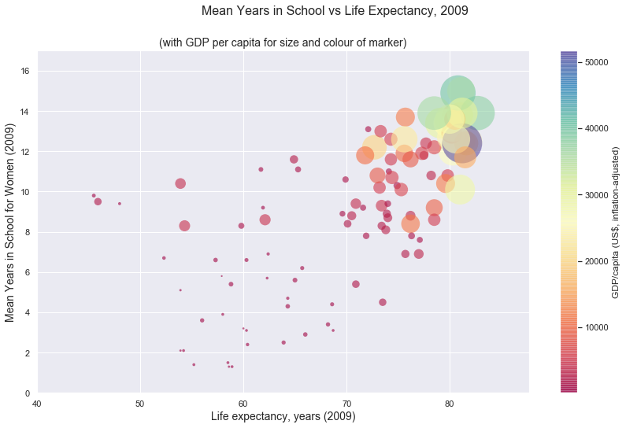

```python
# Adapted from an answer from:
# https://stackoverflow.com/questions/25741214/how-to-use-colormaps-to-color-plots-of-pandas-dataframes
# -------------------------------------------------------------------------

df = df_edu_w_life_gdp_09

cmap = cm.get_cmap('Spectral') # Colour map (there are many others)
plt.figure(figsize=(14, 8))

plt.xlim(40, df['life_2009'].max() + 5)
plt.ylim(0, df['edu_w_2009'].max() + 2)
colours = df['gdp_2009']
markers = df['gdp_2009']/20

plt.scatter(df['life_2009'], df['edu_w_2009'], c=colours, s=markers, cmap=cmap, edgecolor='None', alpha=0.6)

# title and labels
plt.suptitle('Mean Years in School vs Life Expectancy, 2009', fontsize=16)
plt.title('(with GDP per capita for size and colour of marker)', fontsize=14)
plt.xlabel('Life expectancy, years (2009)', fontsize=14)
plt.ylabel('Mean Years in School for Women (2009)', fontsize=14)

cbar = plt.colorbar()
cbar.set_label('GDP/capita (US$, inflation-adjusted)')
plt.show();
```

Unfortuately the amount of missing data in the GDP per capita dataset resulted in only 108 data points. It is, however an interesting plot taking a similar approach to the Gapminder.org site, by adding a third indictor, in this case GDP per capita, for the size and colour of the markers. The largest markers, in blues and greens, indicate a higher GDP per capita and are all in the upper right corner. Despite the small number of data points, what is shown here is suggestive that wealthier countries have a population with a longer Life expectancy and whose women have more years in school. It is also apparent that there are quite a few countries with a GDP in the mid-range, shown by the orange markers, who have mid to high levels of Mean years in school for women as well as Life expectancy.

## Conclusions

The purpose of this investigation was to find out how years in school for women has changed over time, and whether any associations could be observed with other metrics, using indicators from the Gapminder.org collection for Mean years in school, Urban population, Life expectancy and GDP per capita.

Several questions were asked that looked at different aspects of the dataset for Mean years in school for women aged 25 to 34. The first, involving the Mean years in school for women by itself, simply looked at the raw data plotted for all 35 years (1974 to 2009), which showed that there has been a steady upward trend for all countries. Distribution plots for the 1974 and 2009 years reflect this trend.

Grouping the data by region showed that South America as a whole had the greatest increase on average (from 1974 to 2009) compared with the other regions of the world. But looking at countries individually showed that within the top 20 countries from around the world which had the greatest increase in Mean years in school for women from 1974 to 2009, 8 of those 20 are in the Asia West region, and another 4 are from East Asia Pacific.

These top 20 countries have all seen increases of over 6.4 years, and several over 8. An attempt was made to see if there were any possible associations with the other indicators - GDP per capita, Life expectancy and Urban population - that might account for such big changes, however findings were sketchy due to the limited nature of the data.

The first scatter plot at the beginning of the EDA section showed a promising association for Life expectancy and GDP per capita with Mean years in school for women. When plotted together these three indicators produced an interesting visual, despite the amount of missing GDP data. Correlation coefficients indicated moderately high associations for both Life expectancy and on this minimal GDP data.

Overall the picture is promising, if the observed trends seen in the statistics and visuals continues. There is still room for improvement, however there are many countries and in fact all regions that have seen considerable increases in the average number of years in school for women over the 35 years of data used for this investigation.

### References

McKinney, Wes. 2017: *Python for Data Analysis.* USA: O'Reilly

https://pandas.pydata.org/pandas-docs/stable/missing_data.html

https://towardsdatascience.com/seven-clean-steps-to-reshape-your-data-with-pandas-or-how-i-use-python-where-excel-fails-62061f86ef9c  
https://towardsdatascience.com/the-tale-of-missing-values-in-python-c96beb0e8a9d  
https://medium.com/@numanyilmaz61/handling-missing-data-93d3ce5d0161  
https://www.oreilly.com/learning/handling-missing-data  
http://www.informit.com/articles/article.aspx?p=2314818 Effective Python: 4 Best Practices for Function Arguments | Item 18: Reduce Visual Noise with Variable Positional Arguments | InformIT  
http://cmdlinetips.com/2018/03/how-to-make-boxplots-in-python-with-pandas-and-seaborn/_  
http://www.dummies.com/education/math/statistics  
https://matplotlib.org/gallery/subplots_axes_and_figures/subplot.html  
https://jakevdp.github.io/PythonDataScienceHandbook/04.08-multiple-subplots.html

https://stackoverflow.com/questions/29530232/how-to-check-if-any-value-is-nan-in-a-pandas-dataframe  
https://stackoverflow.com/questions/25748683/pandas-sum-dataframe-rows-for-given-columns  
https://stackoverflow.com/questions/39337115/testing-if-a-pandas-dataframe-exists  
https://stackoverflow.com/questions/13886168/how-to-use-the-pass-statement-in-python  
https://stackoverflow.com/questions/13851535/how-to-delete-rows-from-a-pandas-dataframe-based-on-a-conditional-expression  
https://stackoverflow.com/questions/25741214/how-to-use-colormaps-to-color-plots-of-pandas-dataframes  
https://stackoverflow.com/questions/15908371/matplotlib-colorbars-and-its-text-labels